# Aligning HST images to an absolute reference catalog

Note: The notebook in this repository 'Initializtion.ipynb' goes over many of the basic concepts such as the setup of the environment/package installation and should be read first if you are new to HST images, 'DrizzlePac' or 'Astroquery'.

Note: This notebook is based on WFC3 ISR 2017-19: [Aligning HST Images to Gaia: a Faster Mosaicking Workflow](http://www.stsci.edu/hst/wfc3/documents/ISRs/WFC3-2017-19.pdf) and contains a subset of the information/code found in [the repository here](https://github.com/spacetelescope/gaia_alignment). For more information, see the notebook in that repository titled 'Gaia_alignment.ipynb'.

## Introduction

The alignment of HST exposures is a critical step in image stacking/combination performed by software such as `AstroDrizzle`. Generally, a relative alignment is performed that aligns one image (or multiple images) to another image which is designated as the reference image. This makes it so the images are aligned to each other, but the pointing error of the observatory can still cause the images to have incorrect absolute astrometry.

When absolute astrometry is desired, the images can be aligned to an external catalog that is known to be on an absolute frame. In this example, we will provide a workflow to query catalogs such as SDSS and Gaia via the astroquery package, and then align the images to that catalog via TweakReg.

For more information about TweakReg, see the other notebooks in this repository or the **[TweakReg Documentation](https://drizzlepac.readthedocs.io/en/deployment/tweakreg.html)**.

For more information on Astroquery, see the other notebooks in this repository or the **[Astroquery Documentation](https://astroquery.readthedocs.io/en/latest/)**.

```python
import astropy.units as u
import glob
import numpy as np
import matplotlib.pyplot as plt
import os

from astropy.io import fits
from astropy.table import Table
from astropy.units import Quantity
from astropy.coordinates import SkyCoord
from astroquery.gaia import Gaia
from astroquery.mast import Observations
from astroquery.sdss import SDSS

from ccdproc import ImageFileCollection
from IPython.display import Image

from drizzlepac import tweakreg
from drizzlepac import astrodrizzle
```

```
Created TAP+ (v1.2.1) - Connection:
	Host: gea.esac.esa.int
	Use HTTPS: True
	Port: 443
	SSL Port: 443
Created TAP+ (v1.2.1) - Connection:
	Host: geadata.esac.esa.int
	Use HTTPS: True
	Port: 443
	SSL Port: 443
```

```
WARNING: AstropyDeprecationWarning: astropy.extern.six will be removed in 4.0, use the six module directly if it is still needed [astropy.extern.six]
```

[output not shown]

# 1. Download the Data

For this example, we will use WFC3/UVIS images of NGC 6791 from Visit 01 of proposal 12692.

```python
# Get the observation records
obsTable = Observations.query_criteria(obs_id='ibwb01*', proposal_id=12692, obstype='all', filters='F606W')

# Get the listing of data products
products = Observations.get_product_list(obsTable)

# Filter the products for exposures
filtered_products = Observations.filter_products(products, productSubGroupDescription='FLC')

# Show the table
filtered_products
```

*Table masked=True length=3*

| obsID str10 | obs_collection str3 | dataproduct_type str5 | obs_id str31 | description str64 | type str1 | dataURI str97 | productType str9 | productGroupDescription str28 | productSubGroupDescription str8 | productDocumentationURL str1 | project str6 | prvversion str18 | proposal_id str5 | productFilename str44 | size int64 | parent_obsid str10 | dataRights str6 |
| --- | --- | --- | --- | --- | --- | --- | --- | --- | --- | --- | --- | --- | --- | --- | --- | --- | --- |
| 2002940424 | HST | image | ibwb01xqq | DADS FLC file - CTE-corrected calibrated exposure ACS/WFC3 | S | mast:HST/product/ibwb01xqq_flc.fits | SCIENCE | Minimum Recommended Products | FLC | -- | CALWF3 | 3.5.0(Oct-09-2018) | 12692 | ibwb01xqq_flc.fits | 168203520 | 2002940424 | PUBLIC |
| 2002940425 | HST | image | ibwb01xrq | DADS FLC file - CTE-corrected calibrated exposure ACS/WFC3 | S | mast:HST/product/ibwb01xrq_flc.fits | SCIENCE | Minimum Recommended Products | FLC | -- | CALWF3 | 3.5.0(Oct-09-2018) | 12692 | ibwb01xrq_flc.fits | 168203520 | 2002940425 | PUBLIC |
| 2002940428 | HST | image | ibwb01xxq | DADS FLC file - CTE-corrected calibrated exposure ACS/WFC3 | S | mast:HST/product/ibwb01xxq_flc.fits | SCIENCE | Minimum Recommended Products | FLC | -- | CALWF3 | 3.5.0(Oct-09-2018) | 12692 | ibwb01xxq_flc.fits | 168203520 | 2002940428 | PUBLIC |

```python
# Download all the images above
Observations.download_products(filtered_products, mrp_only=False)
```

```
Downloading URL https://mast.stsci.edu/api/v0.1/Download/file?uri=mast:HST/product/ibwb01xqq_flc.fits to ./mastDownload/HST/ibwb01xqq/ibwb01xqq_flc.fits ... [Done]
Downloading URL https://mast.stsci.edu/api/v0.1/Download/file?uri=mast:HST/product/ibwb01xrq_flc.fits to ./mastDownload/HST/ibwb01xrq/ibwb01xrq_flc.fits ... [Done]
Downloading URL https://mast.stsci.edu/api/v0.1/Download/file?uri=mast:HST/product/ibwb01xxq_flc.fits to ./mastDownload/HST/ibwb01xxq/ibwb01xxq_flc.fits ... [Done]
```

*Table length=3*

| Local Path str47 | Status str8 | Message object | URL object |
| --- | --- | --- | --- |
| ./mastDownload/HST/ibwb01xqq/ibwb01xqq_flc.fits | COMPLETE | None | None |
| ./mastDownload/HST/ibwb01xrq/ibwb01xrq_flc.fits | COMPLETE | None | None |
| ./mastDownload/HST/ibwb01xxq/ibwb01xxq_flc.fits | COMPLETE | None | None |

```python
# For convenience, move the products into the current directory.
for flc in glob.glob('./mastDownload/HST/*/*flc.fits'):
    flc_name = os.path.split(flc)[-1]
    os.rename(flc, flc_name)
```

### Inspect the image header

The cell below shows how to query information from the image header using `ImageFileCollection` in `ccdproc`. We see that the 1st exposure is 30 seconds and the 2nd and 3rd exposures are 360 seconds. The 3rd exposure is dithered by ~82" in the Y-direction which is approximately the width of one UVIS chip.

```python
collec = ImageFileCollection('./', glob_include="*flc.fits", ext=0,
                             keywords=["targname", "ra_targ", "dec_targ", "filter", "exptime", "postarg1", "postarg2"])

table = collec.summary
table['exptime'].format = '7.1f'
table['ra_targ'].format = '7.7f'
table['dec_targ'].format = '7.7f'
table['postarg1'].format = '7.2f'
table['postarg2'].format = '7.2f'
table
```

*Table masked=True length=3*

| file str18 | targname str8 | ra_targ float64 | dec_targ float64 | filter str5 | exptime float64 | postarg1 float64 | postarg2 float64 |
| --- | --- | --- | --- | --- | --- | --- | --- |
| ibwb01xqq_flc.fits | NGC-6791 | 290.2247917 | 37.8026667 | F606W | 30.0 | 0.00 | 0.00 |
| ibwb01xrq_flc.fits | NGC-6791 | 290.2247917 | 37.8026667 | F606W | 360.0 | 0.00 | 0.00 |
| ibwb01xxq_flc.fits | NGC-6791 | 290.2247917 | 37.8026667 | F606W | 360.0 | 0.00 | 81.60 |

# 2. Querying catalogs

Now that we have the images, we will download the reference catalogs from both SDSS and Gaia using `astroquery`.

### 2a. Identify Coordinates

We will first create a SkyCoord Object to point astroquery to where we are looking on the sky. Since our example uses data from NGC 6791, we will use the `ra_targ` and `dec_targ` keywords from the first image to get the coordinates of the object.

```python
RA = table['ra_targ'][0]
Dec = table['dec_targ'][0]
```

### 2b. SDSS Query

We now give those values to an astropy `SkyCoord` object, which we will pass to the SDSS. Additionally, we use an astropy `Quantity` object to create a radius for the SDSS query. We set the radius to 6 arcminutes to comfortably cover the area of our images. For reference UVIS detector field of view is ~2.7'x2.7' and a y-dither of 82" covers a total area on the sky of ~2.7'x4.1'.

```python
coord = SkyCoord(ra=RA, dec=Dec, unit=(u.deg, u.deg))
radius = Quantity(6., u.arcmin)
```

Then we only need to perform the query via the `SDSS.query_region` method of `astroquery.sdss`. The `spectro=False` keyword argument means we want to exclude spectroscopic objects, as we are looking for objects to match with an image.

In the fields parameter, we specify a list of fields we want returned by the query. In this case we only need the position, and maybe a magnitude 'g' if we want to cut very dim and/or bright objects out of the catalog, as those are likely measured poorly. Details on selecting objects by magnitude may be found in the original ['Gaia_alignment' notebook](https://github.com/spacetelescope/gaia_alignment). Many other fields are available in the SDSS query and are [documented here](http://cas.sdss.org/dr7/en/help/browser/description.asp?n=PhotoObj&t=V).

```python
sdss_query = SDSS.query_region(coord, radius=radius, spectro=False, fields=['ra', 'dec', 'g'])
sdss_query
```

*Table length=7999*

| ra float64 | dec float64 | g float64 |
| --- | --- | --- |
| 290.207469231001 | 37.8165326473223 | 20.33007 |
| 290.271475371735 | 37.7300895794016 | 15.66874 |
| 290.309189927802 | 37.8278826035946 | 19.63535 |
| 290.163019147038 | 37.7061662746003 | 18.96654 |
| 290.20638291091 | 37.8578498261682 | 19.08411 |
| 290.217665348487 | 37.7344679199735 | 18.97118 |
| 290.28739975944 | 37.8760699685096 | 21.61839 |
| 290.320926423694 | 37.8576064635757 | 18.07215 |
| 290.133686795983 | 37.8548733101238 | 20.47255 |
| 290.203352916518 | 37.7772004873409 | 19.50708 |
| ... | ... | ... |
| 290.169576739813 | 37.8330753301752 | 17.2236 |
| 290.222554874828 | 37.8039952410223 | 19.40186 |
| 290.239484462281 | 37.8797379669369 | 24.90789 |
| 290.143810400052 | 37.7760398705947 | 18.70891 |
| 290.183883965341 | 37.7162283777914 | 25.5072 |
| 290.317687007067 | 37.8443088537163 | 23.08437 |
| 290.322400644443 | 37.7502919120541 | 23.81956 |
| 290.323097414385 | 37.7666614782482 | 20.45473 |
| 290.177872372334 | 37.8422895598552 | -9999.0 |
| 290.309645696512 | 37.8639969341253 | 23.97357 |

We then just need to save the catalog to use with TweakReg. Since the returned value of the query is an `astropy.Table`, saving the file is very straightforward:

```python
sdss_query.write('sdss.cat', format='ascii.commented_header')
```

### 2c. Gaia Query

Similarly to SDSS, we can query Gaia catalogs for our target via `astroquery.gaia`. We can use the same `coord` and `radius` from the SDSS query.

```python
gaia_query = Gaia.query_object_async(coordinate=coord, radius=radius)
gaia_query
```

[output not shown]

[output cut: 21 more lines]

[output not shown]

```
INFO: Query finished. [astroquery.utils.tap.core]
```

*Table masked=True length=5940*

| dist float64 | solution_id int64 | designation object | source_id int64 | random_index int64 | ref_epoch yr float64 | ra deg float64 | ra_error mas float64 | dec deg float64 | dec_error mas float64 | parallax mas float64 | parallax_error mas float64 | parallax_over_error float32 | pmra mas / yr float64 | pmra_error mas / yr float64 | pmdec mas / yr float64 | pmdec_error mas / yr float64 | ra_dec_corr float32 | ra_parallax_corr float32 | ra_pmra_corr float32 | ra_pmdec_corr float32 | dec_parallax_corr float32 | dec_pmra_corr float32 | dec_pmdec_corr float32 | parallax_pmra_corr float32 | parallax_pmdec_corr float32 | pmra_pmdec_corr float32 | astrometric_n_obs_al int32 | astrometric_n_obs_ac int32 | astrometric_n_good_obs_al int32 | … |
| --- | --- | --- | --- | --- | --- | --- | --- | --- | --- | --- | --- | --- | --- | --- | --- | --- | --- | --- | --- | --- | --- | --- | --- | --- | --- | --- | --- | --- | --- | --- |
| 0.0007457750280585006 | 1635721458409799680 | Gaia DR2 2051293319932402944 | 2051293319932402944 | 1675162907 | 2015.5 | 290.2248612117769 | 0.17025317759995298 | 37.801928644334666 | 0.23706526958649082 | 0.9169012687299769 | 0.2320288738061574 | 3.9516687 | -0.7436331528144198 | 0.3812622579469638 | 6.010353940292694 | 0.5025560536657159 | 0.07765845 | 0.19423231 | -0.002706211 | -0.20296262 | 0.26506588 | -0.22303766 | -0.1096294 | -0.17967537 | -0.07058169 | -0.061190978 | 215 | 0 | 214 | … |
| 0.0012110279047063879 | 1635721458409799680 | Gaia DR2 2051293324218263808 | 2051293324218263808 | 1595923736 | 2015.5 | 290.223279633381 | 1.5690004116043692 | 37.80283985940256 | 1.6547840094163826 | -1.320572176475729 | 1.8191390036660162 | -0.72593254 | 0.8761340497979906 | 3.6444323171202093 | -7.467410707407032 | 4.049123128257428 | 0.19615959 | 0.29596093 | -0.54230744 | -0.18939278 | 0.21505406 | -0.27994195 | -0.21801001 | -0.03480102 | -0.25085065 | -0.23204574 | 101 | 0 | 101 | … |
| 0.0017209432799984764 | 1635721458409799680 | Gaia DR2 2051293324222972288 | 2051293324222972288 | 684691353 | 2015.5 | 290.2226200636918 | 0.0401413253744426 | 37.80270788854854 | 0.05565616863010376 | 0.28855328224448124 | 0.055149243226651164 | 5.2322254 | -0.9150164154386746 | 0.09003764471695938 | -2.283986940551454 | 0.11810825030141148 | 0.028360901 | 0.13254215 | 0.021127375 | -0.17511852 | 0.25393003 | -0.19877477 | -0.11458644 | -0.19941486 | -0.056049723 | -0.09359692 | 216 | 0 | 213 | … |
| 0.002086468716503423 | 1635721458409799680 | Gaia DR2 2051293324222972416 | 2051293324222972416 | 1669958886 | 2015.5 | 290.2248310561946 | 0.06775849752700615 | 37.80058642553806 | 0.0923307191165666 | 0.12207343604120367 | 0.09184935737794822 | 1.3290614 | -0.5521414811317894 | 0.1534983713075479 | -2.096187408956107 | 0.19426445417571747 | 0.024605555 | 0.1464805 | 0.010215694 | -0.19162522 | 0.24501786 | -0.19810662 | -0.14569473 | -0.16725567 | -0.12649414 | -0.12028173 | 218 | 0 | 217 | … |
| 0.002197897470933271 | 1635721458409799680 | Gaia DR2 2051293319934791936 | 2051293319934791936 | 1576533293 | 2015.5 | 290.2225603235312 | 0.12993897091392498 | 37.8039787667679 | 0.1780986969353126 | 0.09726577828532874 | 0.1741475443764564 | 0.55852515 | 0.20088484097329717 | 0.2903565979952265 | -2.49480858896227 | 0.36581327072321806 | 0.08523585 | 0.20461641 | -0.020002373 | -0.23607036 | 0.25751892 | -0.24746391 | -0.1802525 | -0.19678932 | -0.12736729 | -0.0596406 | 219 | 0 | 217 | … |
| 0.0022222866783588725 | 1635721458409799680 | Gaia DR2 2051293324216543232 | 2051293324216543232 | 578335417 | 2015.5 | 290.22681932060266 | 0.7994874949121815 | 37.80112775249116 | 1.2305347986326223 | -1.4221031495065748 | 1.1449915961278054 | -1.2420206 | -1.207367952459958 | 2.1264096886778523 | -1.2791571235010868 | 2.3153236892297175 | 0.22157861 | 0.04446491 | -0.46602562 | -0.055103514 | 0.49538702 | -0.10242252 | -0.15146092 | 0.07864887 | -0.18281442 | -0.03817409 | 129 | 0 | 128 | … |
| 0.002298797179471436 | 1635721458409799680 | Gaia DR2 2051293324222974464 | 2051293324222974464 | 839691156 | 2015.5 | 290.2275250867832 | 0.3278227892077287 | 37.80347302560439 | 0.45574332480880614 | 0.06581434033562428 | 0.4443909164323604 | 0.14810011 | -0.5688810655819019 | 0.73267041111987 | -0.8711183963541197 | 1.0253717345695645 | 0.12175131 | 0.23861632 | -0.03843207 | -0.1894876 | 0.27611512 | -0.20986135 | -0.090285234 | -0.12787914 | -0.006394373 | -0.014172757 | 211 | 0 | 209 | … |
| 0.0023203896367113707 | 1635721458409799680 | Gaia DR2 2051293324216539648 | 2051293324216539648 | 1456322683 | 2015.5 | 290.2242323214596 | 0.6901484170040557 | 37.80039574182613 | 1.734655718272211 | 1.6560953005889028 | 1.0044537040850003 | 1.6487522 | -1.7804343799729692 | 1.9637641538789297 | -7.467409785757459 | 3.92346078397992 | -0.3995982 | -0.14981805 | -0.39960223 | 0.32980224 | 0.40864098 | 0.45243028 | -0.67600775 | 0.1952983 | -0.20598729 | -0.6513247 | 126 | 0 | 125 | … |
| 0.002717866586406668 | 1635721458409799680 | Gaia DR2 2051293319938274560 | 2051293319938274560 | 1302226664 | 2015.5 | 290.2230290362595 | 0.5257201966010322 | 37.80034165772993 | 0.7245916000765663 | -- | -- | -- | -- | -- | -- | -- | -0.036536682 | -- | -- | -- | -- | -- | -- | -- | -- | -- | 214 | 0 | 213 | … |
| ... | ... | ... | ... | ... | ... | ... | ... | ... | ... | ... | ... | ... | ... | ... | ... | ... | ... | ... | ... | ... | ... | ... | ... | ... | ... | ... | ... | ... | ... | … |
| 0.0998506192154554 | 1635721458409799680 | Gaia DR2 2051297481746548608 | 2051297481746548608 | 171465077 | 2015.5 | 290.13181656272184 | 0.5985397715735781 | 37.87033156574414 | 0.8112464706446293 | -1.2929379303580213 | 0.8477278628570117 | -1.5251805 | -2.841681427785426 | 1.2616210293931722 | -3.122910214288164 | 1.5040660862806918 | 0.10034987 | 0.193869 | -0.13942271 | -0.17243071 | 0.36721578 | -0.21081237 | -0.07282118 | -0.13721715 | -0.110128775 | -0.05037769 | 158 | 0 | 158 | … |
| 0.09985848035357017 | 1635721458409799680 | Gaia DR2 2051104895415050880 | 2051104895415050880 | 13216479 | 2015.5 | 290.2729229689045 | 0.6549208190197481 | 37.710347194743846 | 1.2242850265567693 | -1.7219555838965592 | 1.11572184433986 | -1.5433556 | 1.5632801828978014 | 1.5800781889965738 | -4.730146898518022 | 2.0373202112146034 | 0.21851616 | 0.2060538 | -0.23260516 | -0.3063561 | 0.5231553 | -0.5305942 | -0.12102173 | -0.4807113 | 0.14948465 | -0.020053968 | 146 | 0 | 145 | … |
| 0.09988437479391063 | 1635721458409799680 | Gaia DR2 2051104822398898560 | 2051104822398898560 | 253340939 | 2015.5 | 290.3450266589569 | 0.04382812362476714 | 37.771869032608755 | 0.0570646038692938 | 0.3543149198868761 | 0.057097179097825794 | 6.2054715 | -4.202916380134663 | 0.09528288444864444 | -3.765745230911082 | 0.11549824024809101 | 0.026373664 | 0.087742046 | -0.07657621 | -0.1680012 | 0.16103107 | -0.1951138 | -0.2266004 | -0.21666312 | -0.009753685 | -0.031661306 | 220 | 0 | 217 | … |
| 0.099886332230141 | 1635721458409799680 | Gaia DR2 2051104276944831232 | 2051104276944831232 | 1202700811 | 2015.5 | 290.30317137512634 | 0.06775734563017259 | 37.724324199852 | 0.08918070163423897 | 0.2100108504964087 | 0.08606078042536477 | 2.440262 | 1.6716411507803655 | 0.1501240619254422 | -2.0556249929793404 | 0.18738792689131195 | 0.04548873 | 0.10820494 | -0.064302556 | -0.2534038 | 0.14158556 | -0.25546888 | -0.20584804 | -0.14277709 | -0.06714995 | -0.0806213 | 229 | 0 | 227 | … |
| 0.09989209814940367 | 1635721458409799680 | Gaia DR2 2051294973490826880 | 2051294973490826880 | 867298686 | 2015.5 | 290.22302836191943 | 0.24429338869446995 | 37.90255505614164 | 0.3443318393985456 | -0.10491725731627698 | 0.33137695399466555 | -0.31661 | -0.5276091688522185 | 0.5531954119648012 | -2.2078832009286025 | 0.7790945192401563 | 0.0930899 | 0.19553098 | 0.013783427 | -0.077881776 | 0.2672394 | -0.056228023 | -0.12598088 | 0.02417464 | -0.027420936 | -0.016621223 | 208 | 0 | 207 | … |
| 0.09989584242819345 | 1635721458409799680 | Gaia DR2 2051099226058013440 | 2051099226058013440 | 1686431293 | 2015.5 | 290.21084762472816 | 0.2463874865672057 | 37.70338765784962 | 0.3982954169117854 | 0.9856784902836552 | 0.3783248901904759 | 2.6053758 | 5.520582876371458 | 0.5914131915244116 | -7.302760014177029 | 0.870007976135641 | 0.030518884 | -0.04961785 | 0.13859044 | -0.26800653 | 0.39752883 | -0.3728997 | 0.02310672 | -0.34190744 | 0.28545266 | 0.0019748088 | 165 | 0 | 165 | … |
| 0.09993918030760596 | 1635721458409799680 | Gaia DR2 2051291464496212480 | 2051291464496212480 | 284106072 | 2015.5 | 290.1069010164186 | 0.1846905103507187 | 37.83892975196812 | 0.2966586600598394 | 0.2901559695935157 | 0.28519241986489974 | 1.0174042 | -3.8336209577370806 | 0.43035299858564846 | -7.33910463081164 | 0.505357368993431 | -0.015017842 | 0.035306104 | -0.0011344639 | -0.038484454 | 0.47730994 | -0.09189697 | -0.16009183 | -0.11143811 | -0.030599764 | -0.042054184 | 232 | 0 | 230 | … |
| 0.09994034884817839 | 1635721458409799680 | Gaia DR2 2051295003549464192 | 2051295003549464192 | 1306488201 | 2015.5 | 290.19975747252914 | 0.24094810614942833 | 37.90063777120111 | 0.33394676144271834 | 0.34321061099816375 | 0.3214278268273543 | 1.0677688 | 0.0028890141788233126 | 0.5432969467360321 | -2.106552053770626 | 0.7321524832031528 | 0.060927846 | 0.18811263 | 0.027939156 | -0.11382915 | 0.23887289 | -0.07422122 | -0.18710355 | 0.0045888107 | -0.11759859 | -0.0808227 | 220 | 0 | 219 | … |
| 0.09996016660386278 | 1635721458409799680 | Gaia DR2 2051297889777267200 | 2051297889777267200 | 288786918 | 2015.5 | 290.16265165469673 | 0.9574039273911054 | 37.889757483037904 | 1.6535205625960843 | 0.38186241438451335 | 1.4935852084656898 | 0.2556683 | -7.34934920137889 | 2.4117090791494653 | -3.220021893017921 | 2.89647098714221 | 0.10694288 | 0.1846134 | -0.34563532 | 0.061065923 | 0.49624652 | 0.102576435 | -0.23283136 | 0.085963845 | -0.18690927 | -0.18872154 | 93 | 0 | 92 | … |
| 0.09998138510053843 | 1635721458409799680 | Gaia DR2 2051286864592101632 | 2051286864592101632 | 81075193 | 2015.5 | 290.18718559805467 | 0.10326466872031764 | 37.7072161411612 | 0.1662711441857896 | -0.02912866610562227 | 0.1616367799223241 | -0.18021064 | -1.8817919718739198 | 0.24511848579261616 | -2.372901544241679 | 0.2604240884575701 | 0.13342427 | 0.06432228 | -0.10165644 | -0.26837683 | 0.5227288 | -0.4607274 | -0.3013406 | -0.46333948 | -0.06613629 | 0.11008046 | 192 | 0 | 192 | … |

This query has returned very large number of columns. We want to pare down the catalog to make it easier to use with `TweakReg`.  
We can select only the useful columns via:

```python
reduced_query = gaia_query['ra', 'dec', 'phot_g_mean_mag']
reduced_query
```

*Table masked=True length=5940*

| ra deg float64 | dec deg float64 | phot_g_mean_mag mag float32 |
| --- | --- | --- |
| 290.2248612117769 | 37.801928644334666 | 18.993488 |
| 290.223279633381 | 37.80283985940256 | 20.828722 |
| 290.2226200636918 | 37.80270788854854 | 16.649422 |
| 290.2248310561946 | 37.80058642553806 | 17.595186 |
| 290.2225603235312 | 37.8039787667679 | 18.654873 |
| 290.22681932060266 | 37.80112775249116 | 20.771065 |
| 290.2275250867832 | 37.80347302560439 | 19.938679 |
| 290.2242323214596 | 37.80039574182613 | 20.654758 |
| 290.2230290362595 | 37.80034165772993 | 18.260427 |
| ... | ... | ... |
| 290.13181656272184 | 37.87033156574414 | 20.386423 |
| 290.2729229689045 | 37.710347194743846 | 20.644482 |
| 290.3450266589569 | 37.771869032608755 | 16.743288 |
| 290.30317137512634 | 37.724324199852 | 17.567339 |
| 290.22302836191943 | 37.90255505614164 | 19.582539 |
| 290.21084762472816 | 37.70338765784962 | 19.372353 |
| 290.1069010164186 | 37.83892975196812 | 19.242018 |
| 290.19975747252914 | 37.90063777120111 | 19.643486 |
| 290.16265165469673 | 37.889757483037904 | 20.95616 |
| 290.18718559805467 | 37.7072161411612 | 18.16055 |

Then we write this catalog to an ascii file for use with `TweakReg`.

```python
reduced_query.write('gaia.cat', format='ascii.commented_header')
```

## 3. Running TweakReg

With the catalogs downloaded and the headers populated, we simply need to run TweakReg with each catalog passed into the `refcat` parameter. The steps below compare the astrometric residuals obtained from aligning to each `refcat`. In each test case, we set `updatehdr` to False until we are satisfied with the alignment by inspecting both the shift file and the astrometric residual plots.

### 3a. SDSS Alignment

```
INFO:drizzlepac.util:Setting up logfile :  tweakreg.log
```

```
Setting up logfile :  tweakreg.log
```

```
INFO:drizzlepac.tweakreg:TweakReg Version 1.4.7(18-April-2018) started at: 01:09:10.207 (18/12/2019)
```

```
TweakReg Version 1.4.7(18-April-2018) started at: 01:09:10.207 (18/12/2019)
```

```
INFO:drizzlepac.tweakreg:
```

```
INFO:drizzlepac.util:Version Information
```

```
Version Information
```

```
INFO:drizzlepac.util:--------------------
```

```
INFO:drizzlepac.util:Python Version [Clang 4.0.1 (tags/RELEASE_401/final)]
```

```
Python Version [Clang 4.0.1 (tags/RELEASE_401/final)]
```

```
INFO:drizzlepac.util:3.7.5 (default, Oct 25 2019, 10:52:18)
```

```
3.7.5 (default, Oct 25 2019, 10:52:18)
```

```
INFO:drizzlepac.util:numpy Version -> 1.17.4
```

```
numpy Version -> 1.17.4
```

```
INFO:drizzlepac.util:astropy Version -> 3.2.3
```

```
astropy Version -> 3.2.3
```

```
INFO:drizzlepac.util:stwcs Version -> 1.5.3
```

```
stwcs Version -> 1.5.3
```

```
INFO:drizzlepac.tweakreg:
INFO:drizzlepac.tweakreg:USER INPUT PARAMETERS common to all Processing Steps:
INFO:drizzlepac.tweakreg:	clean :	False
INFO:drizzlepac.tweakreg:	enforce_user_order :	True
INFO:drizzlepac.tweakreg:	exclusions :
INFO:drizzlepac.tweakreg:	expand_refcat :	False
INFO:drizzlepac.tweakreg:	input :	*flc.fits
INFO:drizzlepac.tweakreg:	interactive :	False
INFO:drizzlepac.tweakreg:	refimage :
INFO:drizzlepac.tweakreg:	runfile :	tweakreg.log
INFO:drizzlepac.tweakreg:	updatewcs :	False
INFO:drizzlepac.tweakreg:	verbose :	False
INFO:drizzlepac.tweakreg:	writecat :	True
INFO:drizzlepac.tweakreg:
```

```
INFO:drizzlepac.tweakreg:Finding shifts for:
```

```
Finding shifts for:
```

```
INFO:drizzlepac.tweakreg:    ibwb01xrq_flc.fits
```

```
    ibwb01xrq_flc.fits
```

```
INFO:drizzlepac.tweakreg:    ibwb01xxq_flc.fits
```

```
    ibwb01xxq_flc.fits
```

```
INFO:drizzlepac.tweakreg:    ibwb01xqq_flc.fits
```

```
    ibwb01xqq_flc.fits
```

```
INFO:drizzlepac.tweakreg:
```

[output not shown]

```
===  Source finding for image 'ibwb01xrq_flc.fits':
```

```
INFO:drizzlepac.catalogs:  #  Source finding for 'ibwb01xrq_flc.fits', EXT=('SCI', 1) started at: 01:09:10.443 (18/12/2019)
```

```
  #  Source finding for 'ibwb01xrq_flc.fits', EXT=('SCI', 1) started at: 01:09:10.443 (18/12/2019)
```

```
INFO:drizzlepac.catalogs:   Finding sources using sky sigma = 5.638966
INFO:drizzlepac.catalogs:###Source finding finished at: 01:09:11.303 (18/12/2019)
INFO:drizzlepac.catalogs:     Found 1363 objects.
```

```
     Found 1363 objects.
```

```
INFO:drizzlepac.catalogs:  #  Source finding for 'ibwb01xrq_flc.fits', EXT=('SCI', 2) started at: 01:09:11.370 (18/12/2019)
```

```
  #  Source finding for 'ibwb01xrq_flc.fits', EXT=('SCI', 2) started at: 01:09:11.370 (18/12/2019)
```

```
INFO:drizzlepac.catalogs:   Finding sources using sky sigma = 5.682907
INFO:drizzlepac.catalogs:###Source finding finished at: 01:09:12.168 (18/12/2019)
INFO:drizzlepac.catalogs:     Found 1313 objects.
```

```
     Found 1313 objects.
```

```
INFO:drizzlepac.imgclasses:===  FINAL number of objects in image 'ibwb01xrq_flc.fits': 2676
```

```
===  FINAL number of objects in image 'ibwb01xrq_flc.fits': 2676
```

```
INFO:drizzlepac.imgclasses:
```

```
INFO:drizzlepac.imgclasses:===  Source finding for image 'ibwb01xxq_flc.fits':
```

```
===  Source finding for image 'ibwb01xxq_flc.fits':
```

```
INFO:drizzlepac.catalogs:  #  Source finding for 'ibwb01xxq_flc.fits', EXT=('SCI', 1) started at: 01:09:12.395 (18/12/2019)
```

```
  #  Source finding for 'ibwb01xxq_flc.fits', EXT=('SCI', 1) started at: 01:09:12.395 (18/12/2019)
```

```
INFO:drizzlepac.catalogs:   Finding sources using sky sigma = 4.939314
INFO:drizzlepac.catalogs:###Source finding finished at: 01:09:13.205 (18/12/2019)
INFO:drizzlepac.catalogs:     Found 1836 objects.
```

```
     Found 1836 objects.
```

```
INFO:drizzlepac.catalogs:  #  Source finding for 'ibwb01xxq_flc.fits', EXT=('SCI', 2) started at: 01:09:13.278 (18/12/2019)
```

```
  #  Source finding for 'ibwb01xxq_flc.fits', EXT=('SCI', 2) started at: 01:09:13.278 (18/12/2019)
```

```
INFO:drizzlepac.catalogs:   Finding sources using sky sigma = 4.820505
INFO:drizzlepac.catalogs:###Source finding finished at: 01:09:14.10 (18/12/2019)
INFO:drizzlepac.catalogs:     Found 2008 objects.
```

```
     Found 2008 objects.
```

```
INFO:drizzlepac.imgclasses:===  FINAL number of objects in image 'ibwb01xxq_flc.fits': 3844
```

```
===  FINAL number of objects in image 'ibwb01xxq_flc.fits': 3844
```

```
INFO:drizzlepac.imgclasses:
```

```
INFO:drizzlepac.imgclasses:===  Source finding for image 'ibwb01xqq_flc.fits':
```

```
===  Source finding for image 'ibwb01xqq_flc.fits':
```

```
INFO:drizzlepac.catalogs:  #  Source finding for 'ibwb01xqq_flc.fits', EXT=('SCI', 1) started at: 01:09:14.316 (18/12/2019)
```

```
  #  Source finding for 'ibwb01xqq_flc.fits', EXT=('SCI', 1) started at: 01:09:14.316 (18/12/2019)
```

```
INFO:drizzlepac.catalogs:   Finding sources using sky sigma = 1.846397
INFO:drizzlepac.catalogs:###Source finding finished at: 01:09:15.117 (18/12/2019)
INFO:drizzlepac.catalogs:     Found 1364 objects.
```

```
     Found 1364 objects.
```

```
INFO:drizzlepac.catalogs:  #  Source finding for 'ibwb01xqq_flc.fits', EXT=('SCI', 2) started at: 01:09:15.184 (18/12/2019)
```

```
  #  Source finding for 'ibwb01xqq_flc.fits', EXT=('SCI', 2) started at: 01:09:15.184 (18/12/2019)
```

```
INFO:drizzlepac.catalogs:   Finding sources using sky sigma = 0.389856
INFO:drizzlepac.catalogs:###Source finding finished at: 01:09:16.016 (18/12/2019)
INFO:drizzlepac.catalogs:     Found 2137 objects.
```

```
     Found 2137 objects.
```

```
INFO:drizzlepac.imgclasses:===  FINAL number of objects in image 'ibwb01xqq_flc.fits': 3501
```

```
===  FINAL number of objects in image 'ibwb01xqq_flc.fits': 3501
```

```
INFO:drizzlepac.imgclasses:
```

[output not shown]

```
INFO:drizzlepac.tweakreg:===============================================================
```

```
INFO:drizzlepac.tweakreg:Performing alignment in the projection plane defined by the WCS
```

```
Performing alignment in the projection plane defined by the WCS
```

```
INFO:drizzlepac.tweakreg:derived from 'ibwb01xrq_flc.fits'
```

```
derived from 'ibwb01xrq_flc.fits'
```

```
INFO:drizzlepac.tweakreg:===============================================================
```

```
INFO:drizzlepac.tweakreg:
```

[output not shown]

```
INFO:drizzlepac.tweakreg:====================
```

```
INFO:drizzlepac.tweakreg:Performing fit for: ibwb01xrq_flc.fits
```

```
Performing fit for: ibwb01xrq_flc.fits
```

```
INFO:drizzlepac.tweakreg:
```

```
INFO:drizzlepac.imgclasses:Matching sources from 'ibwb01xrq_flc.fits' with sources from reference catalog 'sdss.cat'
```

```
Matching sources from 'ibwb01xrq_flc.fits' with sources from reference catalog 'sdss.cat'
```

```
INFO:drizzlepac.imgclasses:Computing initial guess for X and Y shifts...
```

```
Computing initial guess for X and Y shifts...
```

```
INFO:drizzlepac.imgclasses:Found initial X and Y shifts of 5.758, -6.13 with significance of 69.78 and 548 matches
```

```
Found initial X and Y shifts of 5.758, -6.13 with significance of 69.78 and 548 matches
```

```
INFO:drizzlepac.imgclasses:Found 234 matches for ibwb01xrq_flc.fits...
```

```
Found 234 matches for ibwb01xrq_flc.fits...
```

```
INFO:drizzlepac.linearfit:Performing "general" fit
INFO:drizzlepac.linearfit:Performing "general" fit
INFO:drizzlepac.linearfit:Performing "general" fit
INFO:drizzlepac.linearfit:Performing "general" fit
INFO:drizzlepac.imgclasses:Computed  general  fit for  ibwb01xrq_flc.fits :
```

```
Computed  general  fit for  ibwb01xrq_flc.fits :
```

```
INFO:drizzlepac.imgclasses:XSH: 5.7834  YSH: -6.3216    PROPER ROT: 0.002689473574
```

```
XSH: 5.7834  YSH: -6.3216    PROPER ROT: 0.002689473574
```

```
INFO:drizzlepac.imgclasses:<ROT>: 180.0026895  SKEW: -359.9937629    ROT_X: 359.9995709  ROT_Y: 0.005808002503
```

```
<ROT>: 180.0026895  SKEW: -359.9937629    ROT_X: 359.9995709  ROT_Y: 0.005808002503
```

```
INFO:drizzlepac.imgclasses:<SCALE>: 1.00007296  SCALE_X: 1.000025367  SCALE_Y: 1.000120561
```

```
<SCALE>: 1.00007296  SCALE_X: 1.000025367  SCALE_Y: 1.000120561
```

```
INFO:drizzlepac.imgclasses:FIT XRMS: 0.37       FIT YRMS: 0.51
```

```
FIT XRMS: 0.37       FIT YRMS: 0.51
```

```
INFO:drizzlepac.imgclasses:FIT RMSE: 0.63       FIT MAE: 0.57
```

```
FIT RMSE: 0.63       FIT MAE: 0.57
```

```
INFO:drizzlepac.imgclasses:
```

```
INFO:drizzlepac.imgclasses:RMS_RA: 8.8e-06 (deg)   RMS_DEC: 2.1e-07 (deg)
```

```
RMS_RA: 8.8e-06 (deg)   RMS_DEC: 2.1e-07 (deg)
```

```
INFO:drizzlepac.imgclasses:
```

```
INFO:drizzlepac.imgclasses:Final solution based on  234  objects.
```

```
Final solution based on  234  objects.
```

```
INFO:drizzlepac.imgclasses:Creating catalog for the fit: ibwb01xrq_flc_catalog_fit.match
INFO:drizzlepac.tweakutils:wrote XY data to:  ibwb01xrq_flc_catalog_fit.match
```

```
wrote XY data to:  ibwb01xrq_flc_catalog_fit.match
```

```
INFO:drizzlepac.tweakutils:Total # points: 234
```

```
Total # points: 234
```

```
INFO:drizzlepac.tweakutils:# of points after clipping: 234
```

```
# of points after clipping: 234
```

```
INFO:drizzlepac.tweakutils:Total # points: 234
```

```
Total # points: 234
```

```
INFO:drizzlepac.tweakutils:# of points after clipping: 234
```

```
# of points after clipping: 234
```

```
INFO:drizzlepac.updatehdr:....Updating header for ibwb01xrq_flc.fits...
INFO:drizzlepac.updatehdr:Processing ibwb01xrq_flc.fits['SCI',1]
INFO:drizzlepac.updatehdr:Updating header for ibwb01xrq_flc.fits[1]
INFO:drizzlepac.updatehdr:Processing ibwb01xrq_flc.fits['SCI',2]
INFO:drizzlepac.updatehdr:Updating header for ibwb01xrq_flc.fits[4]
INFO:drizzlepac.tweakreg:
```

```
INFO:drizzlepac.tweakreg:====================
```

```
INFO:drizzlepac.tweakreg:Performing fit for: ibwb01xxq_flc.fits
```

```
Performing fit for: ibwb01xxq_flc.fits
```

```
INFO:drizzlepac.tweakreg:
```

```
INFO:drizzlepac.imgclasses:Matching sources from 'ibwb01xxq_flc.fits' with sources from reference catalog 'sdss.cat'
```

```
Matching sources from 'ibwb01xxq_flc.fits' with sources from reference catalog 'sdss.cat'
```

```
INFO:drizzlepac.imgclasses:Computing initial guess for X and Y shifts...
```

```
Computing initial guess for X and Y shifts...
```

```
INFO:drizzlepac.imgclasses:Found initial X and Y shifts of 5.93, -7.117 with significance of 90.64 and 515 matches
```

```
Found initial X and Y shifts of 5.93, -7.117 with significance of 90.64 and 515 matches
```

```
INFO:drizzlepac.imgclasses:Found 65 matches for ibwb01xxq_flc.fits...
```

```
Found 65 matches for ibwb01xxq_flc.fits...
```

```
INFO:drizzlepac.linearfit:Performing "general" fit
INFO:drizzlepac.linearfit:Performing "general" fit
INFO:drizzlepac.linearfit:Performing "general" fit
INFO:drizzlepac.linearfit:Performing "general" fit
INFO:drizzlepac.imgclasses:Computed  general  fit for  ibwb01xxq_flc.fits :
```

```
Computed  general  fit for  ibwb01xxq_flc.fits :
```

```
INFO:drizzlepac.imgclasses:XSH: 6.0916  YSH: -6.7981    PROPER ROT: 359.9996333
```

```
XSH: 6.0916  YSH: -6.7981    PROPER ROT: 359.9996333
```

```
INFO:drizzlepac.imgclasses:<ROT>: 359.9996333  SKEW: -0.0006069343121    ROT_X: 359.9999367  ROT_Y: 359.9993298
```

```
<ROT>: 359.9996333  SKEW: -0.0006069343121    ROT_X: 359.9999367  ROT_Y: 359.9993298
```

```
INFO:drizzlepac.imgclasses:<SCALE>: 1.000013878  SCALE_X: 1.000072226  SCALE_Y: 0.999955533
```

```
<SCALE>: 1.000013878  SCALE_X: 1.000072226  SCALE_Y: 0.999955533
```

```
INFO:drizzlepac.imgclasses:FIT XRMS: 0.44       FIT YRMS: 0.45
```

```
FIT XRMS: 0.44       FIT YRMS: 0.45
```

```
INFO:drizzlepac.imgclasses:FIT RMSE: 0.63       FIT MAE: 0.57
```

```
FIT RMSE: 0.63       FIT MAE: 0.57
```

```
INFO:drizzlepac.imgclasses:
```

```
INFO:drizzlepac.imgclasses:RMS_RA: 8.7e-06 (deg)   RMS_DEC: 1.2e-06 (deg)
```

```
RMS_RA: 8.7e-06 (deg)   RMS_DEC: 1.2e-06 (deg)
```

```
INFO:drizzlepac.imgclasses:
```

```
INFO:drizzlepac.imgclasses:Final solution based on  65  objects.
```

```
Final solution based on  65  objects.
```

```
INFO:drizzlepac.imgclasses:Creating catalog for the fit: ibwb01xxq_flc_catalog_fit.match
INFO:drizzlepac.tweakutils:wrote XY data to:  ibwb01xxq_flc_catalog_fit.match
```

```
wrote XY data to:  ibwb01xxq_flc_catalog_fit.match
```

```
INFO:drizzlepac.tweakutils:Total # points: 65
```

```
Total # points: 65
```

```
INFO:drizzlepac.tweakutils:# of points after clipping: 65
```

```
# of points after clipping: 65
```

```
INFO:drizzlepac.tweakutils:Total # points: 65
```

```
Total # points: 65
```

```
INFO:drizzlepac.tweakutils:# of points after clipping: 65
```

```
# of points after clipping: 65
```

```
INFO:drizzlepac.updatehdr:....Updating header for ibwb01xxq_flc.fits...
INFO:drizzlepac.updatehdr:Processing ibwb01xxq_flc.fits['SCI',1]
INFO:drizzlepac.updatehdr:Updating header for ibwb01xxq_flc.fits[1]
INFO:drizzlepac.updatehdr:Processing ibwb01xxq_flc.fits['SCI',2]
INFO:drizzlepac.updatehdr:Updating header for ibwb01xxq_flc.fits[4]
INFO:drizzlepac.tweakreg:
```

```
INFO:drizzlepac.tweakreg:====================
```

```
INFO:drizzlepac.tweakreg:Performing fit for: ibwb01xqq_flc.fits
```

```
Performing fit for: ibwb01xqq_flc.fits
```

```
INFO:drizzlepac.tweakreg:
```

```
INFO:drizzlepac.imgclasses:Matching sources from 'ibwb01xqq_flc.fits' with sources from reference catalog 'sdss.cat'
```

```
Matching sources from 'ibwb01xqq_flc.fits' with sources from reference catalog 'sdss.cat'
```

```
INFO:drizzlepac.imgclasses:Computing initial guess for X and Y shifts...
```

```
Computing initial guess for X and Y shifts...
```

```
INFO:drizzlepac.imgclasses:Found initial X and Y shifts of 5.777, -6.09 with significance of 74.8 and 564 matches
```

```
Found initial X and Y shifts of 5.777, -6.09 with significance of 74.8 and 564 matches
```

```
INFO:drizzlepac.imgclasses:Found 237 matches for ibwb01xqq_flc.fits...
```

```
Found 237 matches for ibwb01xqq_flc.fits...
```

```
INFO:drizzlepac.linearfit:Performing "general" fit
INFO:drizzlepac.linearfit:Performing "general" fit
INFO:drizzlepac.linearfit:Performing "general" fit
INFO:drizzlepac.linearfit:Performing "general" fit
INFO:drizzlepac.imgclasses:Computed  general  fit for  ibwb01xqq_flc.fits :
```

```
Computed  general  fit for  ibwb01xqq_flc.fits :
```

```
INFO:drizzlepac.imgclasses:XSH: 5.8226  YSH: -6.2815    PROPER ROT: 0.001607948819
```

```
XSH: 5.8226  YSH: -6.2815    PROPER ROT: 0.001607948819
```

```
INFO:drizzlepac.imgclasses:<ROT>: 180.0016079  SKEW: -359.9918373    ROT_X: 359.9975266  ROT_Y: 0.005689305896
```

```
<ROT>: 180.0016079  SKEW: -359.9918373    ROT_X: 359.9975266  ROT_Y: 0.005689305896
```

```
INFO:drizzlepac.imgclasses:<SCALE>: 1.00006687  SCALE_X: 1.000020148  SCALE_Y: 1.000113605
```

```
<SCALE>: 1.00006687  SCALE_X: 1.000020148  SCALE_Y: 1.000113605
```

```
INFO:drizzlepac.imgclasses:FIT XRMS: 0.36       FIT YRMS: 0.5
```

```
FIT XRMS: 0.36       FIT YRMS: 0.5
```

```
INFO:drizzlepac.imgclasses:FIT RMSE: 0.62       FIT MAE: 0.56
```

```
FIT RMSE: 0.62       FIT MAE: 0.56
```

```
INFO:drizzlepac.imgclasses:
```

```
INFO:drizzlepac.imgclasses:RMS_RA: 8.6e-06 (deg)   RMS_DEC: 2.2e-07 (deg)
```

```
RMS_RA: 8.6e-06 (deg)   RMS_DEC: 2.2e-07 (deg)
```

```
INFO:drizzlepac.imgclasses:
```

```
INFO:drizzlepac.imgclasses:Final solution based on  237  objects.
```

```
Final solution based on  237  objects.
```

```
INFO:drizzlepac.imgclasses:Creating catalog for the fit: ibwb01xqq_flc_catalog_fit.match
INFO:drizzlepac.tweakutils:wrote XY data to:  ibwb01xqq_flc_catalog_fit.match
```

```
wrote XY data to:  ibwb01xqq_flc_catalog_fit.match
```

```
INFO:drizzlepac.tweakutils:Total # points: 237
```

```
Total # points: 237
```

```
INFO:drizzlepac.tweakutils:# of points after clipping: 237
```

```
# of points after clipping: 237
```

```
INFO:drizzlepac.tweakutils:Total # points: 237
```

```
Total # points: 237
```

```
INFO:drizzlepac.tweakutils:# of points after clipping: 237
```

```
# of points after clipping: 237
```

```
INFO:drizzlepac.updatehdr:....Updating header for ibwb01xqq_flc.fits...
INFO:drizzlepac.updatehdr:Processing ibwb01xqq_flc.fits['SCI',1]
INFO:drizzlepac.updatehdr:Updating header for ibwb01xqq_flc.fits[1]
INFO:drizzlepac.updatehdr:Processing ibwb01xqq_flc.fits['SCI',2]
INFO:drizzlepac.updatehdr:Updating header for ibwb01xqq_flc.fits[4]
INFO:drizzlepac.tweakutils:Writing out shiftfile : SDSS_shifts.txt
```

```
Writing out shiftfile : SDSS_shifts.txt
```

```
INFO:drizzlepac.util:Trailer file written to:  tweakreg.log
```

```
Trailer file written to:  tweakreg.log
```

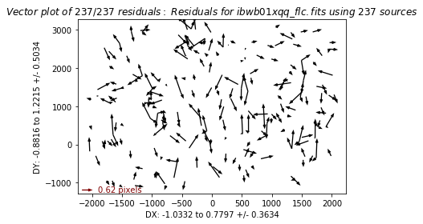

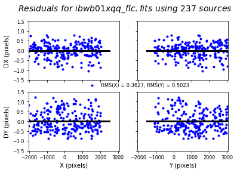

```python
refcat = 'sdss.cat'
cw = 3.5  # Set to two times the FWHM of the PSF of the UVIS detector
wcsname = 'SDSS'  # Specify the WCS name for this alignment

tweakreg.TweakReg('*flc.fits',  # Pass input images
                  updatehdr=False,  # update header with new WCS solution
                  imagefindcfg={'threshold': 500., 'conv_width': cw},  # Detection parameters, threshold varies for different data
                  refcat=refcat,  # Use user supplied catalog (Gaia)
                  interactive=False,
                  see2dplot=False,
                  shiftfile=True,  # Save out shift file (so we can look at shifts later)
                  outshifts='SDSS_shifts.txt',  # name of the shift file
                  wcsname=wcsname,  # Give our WCS a new name
                  reusename=True,
                  ylimit=1.5,
                  fitgeometry='general')  # Use the 6 parameter fit
```

We can look at the shift file to see how well the fit did (or we could open the output png images for more information).

The columns are:

- Filename
- X Shift [pixels]
- Y Shift [pixels]
- Rotation [degrees]
- Scale
- X RMS [pixels]
- Y RMS [pixels]

```python
for line in open('SDSS_shifts.txt').readlines():
    print(line)
```

```
# frame: output

# refimage: shifts_wcs.fits[wcs]

# form: delta

# units: pixels

ibwb01xrq_flc.fits    5.783363  -6.321602    0.002689     1.000073   0.368195  0.512831

ibwb01xxq_flc.fits    6.091640  -6.798055    359.999633     1.000014   0.439761  0.454810

ibwb01xqq_flc.fits    5.822589  -6.281475    0.001608     1.000067   0.362659  0.502291
```

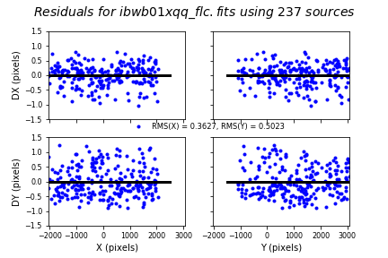

```python
# Astrometric residual plots
Image(filename='residuals_ibwb01xqq_flc.png',width=500, height=300)
```

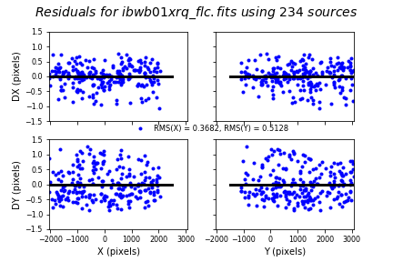

```python
Image(filename='residuals_ibwb01xrq_flc.png',width=500, height=300)
```

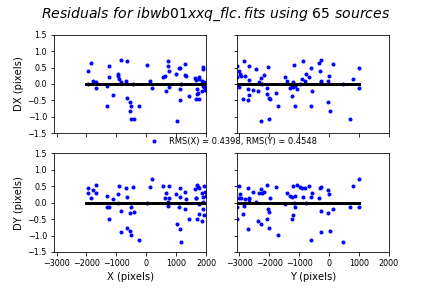

```python
Image(filename='residuals_ibwb01xxq_flc.png',width=500, height=300)
```

### 3b. Gaia Alignment

```
INFO:drizzlepac.util:Setting up logfile :  tweakreg.log
```

```
Setting up logfile :  tweakreg.log
```

```
INFO:drizzlepac.tweakreg:TweakReg Version 1.4.7(18-April-2018) started at: 01:09:19.801 (18/12/2019)
```

```
TweakReg Version 1.4.7(18-April-2018) started at: 01:09:19.801 (18/12/2019)
```

```
INFO:drizzlepac.tweakreg:
```

```
INFO:drizzlepac.util:Version Information
```

```
Version Information
```

```
INFO:drizzlepac.util:--------------------
```

```
INFO:drizzlepac.util:Python Version [Clang 4.0.1 (tags/RELEASE_401/final)]
```

```
Python Version [Clang 4.0.1 (tags/RELEASE_401/final)]
```

```
INFO:drizzlepac.util:3.7.5 (default, Oct 25 2019, 10:52:18)
```

```
3.7.5 (default, Oct 25 2019, 10:52:18)
```

```
INFO:drizzlepac.util:numpy Version -> 1.17.4
```

```
numpy Version -> 1.17.4
```

```
INFO:drizzlepac.util:astropy Version -> 3.2.3
```

```
astropy Version -> 3.2.3
```

```
INFO:drizzlepac.util:stwcs Version -> 1.5.3
```

```
stwcs Version -> 1.5.3
```

```
INFO:drizzlepac.tweakreg:
INFO:drizzlepac.tweakreg:USER INPUT PARAMETERS common to all Processing Steps:
INFO:drizzlepac.tweakreg:	clean :	False
INFO:drizzlepac.tweakreg:	enforce_user_order :	True
INFO:drizzlepac.tweakreg:	exclusions :
INFO:drizzlepac.tweakreg:	expand_refcat :	False
INFO:drizzlepac.tweakreg:	input :	*flc.fits
INFO:drizzlepac.tweakreg:	interactive :	False
INFO:drizzlepac.tweakreg:	refimage :
INFO:drizzlepac.tweakreg:	runfile :	tweakreg.log
INFO:drizzlepac.tweakreg:	updatewcs :	False
INFO:drizzlepac.tweakreg:	verbose :	False
INFO:drizzlepac.tweakreg:	writecat :	True
INFO:drizzlepac.tweakreg:
```

```
INFO:drizzlepac.tweakreg:Finding shifts for:
```

```
Finding shifts for:
```

```
INFO:drizzlepac.tweakreg:    ibwb01xrq_flc.fits
```

```
    ibwb01xrq_flc.fits
```

```
INFO:drizzlepac.tweakreg:    ibwb01xxq_flc.fits
```

```
    ibwb01xxq_flc.fits
```

```
INFO:drizzlepac.tweakreg:    ibwb01xqq_flc.fits
```

```
    ibwb01xqq_flc.fits
```

```
INFO:drizzlepac.tweakreg:
```

[output not shown]

```
===  Source finding for image 'ibwb01xrq_flc.fits':
```

```
INFO:drizzlepac.catalogs:  #  Source finding for 'ibwb01xrq_flc.fits', EXT=('SCI', 1) started at: 01:09:19.948 (18/12/2019)
```

```
  #  Source finding for 'ibwb01xrq_flc.fits', EXT=('SCI', 1) started at: 01:09:19.948 (18/12/2019)
```

```
INFO:drizzlepac.catalogs:   Finding sources using sky sigma = 5.638966
INFO:drizzlepac.catalogs:###Source finding finished at: 01:09:20.749 (18/12/2019)
INFO:drizzlepac.catalogs:     Found 1363 objects.
```

```
     Found 1363 objects.
```

```
INFO:drizzlepac.catalogs:  #  Source finding for 'ibwb01xrq_flc.fits', EXT=('SCI', 2) started at: 01:09:20.816 (18/12/2019)
```

```
  #  Source finding for 'ibwb01xrq_flc.fits', EXT=('SCI', 2) started at: 01:09:20.816 (18/12/2019)
```

```
INFO:drizzlepac.catalogs:   Finding sources using sky sigma = 5.682907
INFO:drizzlepac.catalogs:###Source finding finished at: 01:09:21.62 (18/12/2019)
INFO:drizzlepac.catalogs:     Found 1313 objects.
```

```
     Found 1313 objects.
```

```
INFO:drizzlepac.imgclasses:===  FINAL number of objects in image 'ibwb01xrq_flc.fits': 2676
```

```
===  FINAL number of objects in image 'ibwb01xrq_flc.fits': 2676
```

```
INFO:drizzlepac.imgclasses:
```

```
INFO:drizzlepac.imgclasses:===  Source finding for image 'ibwb01xxq_flc.fits':
```

```
===  Source finding for image 'ibwb01xxq_flc.fits':
```

```
INFO:drizzlepac.catalogs:  #  Source finding for 'ibwb01xxq_flc.fits', EXT=('SCI', 1) started at: 01:09:21.845 (18/12/2019)
```

```
  #  Source finding for 'ibwb01xxq_flc.fits', EXT=('SCI', 1) started at: 01:09:21.845 (18/12/2019)
```

```
INFO:drizzlepac.catalogs:   Finding sources using sky sigma = 4.939314
INFO:drizzlepac.catalogs:###Source finding finished at: 01:09:22.656 (18/12/2019)
INFO:drizzlepac.catalogs:     Found 1836 objects.
```

```
     Found 1836 objects.
```

```
INFO:drizzlepac.catalogs:  #  Source finding for 'ibwb01xxq_flc.fits', EXT=('SCI', 2) started at: 01:09:22.729 (18/12/2019)
```

```
  #  Source finding for 'ibwb01xxq_flc.fits', EXT=('SCI', 2) started at: 01:09:22.729 (18/12/2019)
```

```
INFO:drizzlepac.catalogs:   Finding sources using sky sigma = 4.820505
INFO:drizzlepac.catalogs:###Source finding finished at: 01:09:23.553 (18/12/2019)
INFO:drizzlepac.catalogs:     Found 2008 objects.
```

```
     Found 2008 objects.
```

```
INFO:drizzlepac.imgclasses:===  FINAL number of objects in image 'ibwb01xxq_flc.fits': 3844
```

```
===  FINAL number of objects in image 'ibwb01xxq_flc.fits': 3844
```

```
INFO:drizzlepac.imgclasses:
```

```
INFO:drizzlepac.imgclasses:===  Source finding for image 'ibwb01xqq_flc.fits':
```

```
===  Source finding for image 'ibwb01xqq_flc.fits':
```

```
INFO:drizzlepac.catalogs:  #  Source finding for 'ibwb01xqq_flc.fits', EXT=('SCI', 1) started at: 01:09:23.764 (18/12/2019)
```

```
  #  Source finding for 'ibwb01xqq_flc.fits', EXT=('SCI', 1) started at: 01:09:23.764 (18/12/2019)
```

```
INFO:drizzlepac.catalogs:   Finding sources using sky sigma = 1.846397
INFO:drizzlepac.catalogs:###Source finding finished at: 01:09:24.563 (18/12/2019)
INFO:drizzlepac.catalogs:     Found 1364 objects.
```

```
     Found 1364 objects.
```

```
INFO:drizzlepac.catalogs:  #  Source finding for 'ibwb01xqq_flc.fits', EXT=('SCI', 2) started at: 01:09:24.629 (18/12/2019)
```

```
  #  Source finding for 'ibwb01xqq_flc.fits', EXT=('SCI', 2) started at: 01:09:24.629 (18/12/2019)
```

```
INFO:drizzlepac.catalogs:   Finding sources using sky sigma = 0.389856
INFO:drizzlepac.catalogs:###Source finding finished at: 01:09:25.530 (18/12/2019)
INFO:drizzlepac.catalogs:     Found 2137 objects.
```

```
     Found 2137 objects.
```

```
INFO:drizzlepac.imgclasses:===  FINAL number of objects in image 'ibwb01xqq_flc.fits': 3501
```

```
===  FINAL number of objects in image 'ibwb01xqq_flc.fits': 3501
```

```
INFO:drizzlepac.imgclasses:
```

[output not shown]

```
INFO:drizzlepac.tweakreg:===============================================================
```

```
INFO:drizzlepac.tweakreg:Performing alignment in the projection plane defined by the WCS
```

```
Performing alignment in the projection plane defined by the WCS
```

```
INFO:drizzlepac.tweakreg:derived from 'ibwb01xrq_flc.fits'
```

```
derived from 'ibwb01xrq_flc.fits'
```

```
INFO:drizzlepac.tweakreg:===============================================================
```

```
INFO:drizzlepac.tweakreg:
```

[output not shown]

```
INFO:drizzlepac.tweakreg:====================
```

```
INFO:drizzlepac.tweakreg:Performing fit for: ibwb01xrq_flc.fits
```

```
Performing fit for: ibwb01xrq_flc.fits
```

```
INFO:drizzlepac.tweakreg:
```

```
INFO:drizzlepac.imgclasses:Matching sources from 'ibwb01xrq_flc.fits' with sources from reference catalog 'gaia.cat'
```

```
Matching sources from 'ibwb01xrq_flc.fits' with sources from reference catalog 'gaia.cat'
```

```
INFO:drizzlepac.imgclasses:Computing initial guess for X and Y shifts...
```

```
Computing initial guess for X and Y shifts...
```

```
INFO:drizzlepac.imgclasses:Found initial X and Y shifts of 4.219, -6.289 with significance of 152.3 and 702 matches
```

```
Found initial X and Y shifts of 4.219, -6.289 with significance of 152.3 and 702 matches
```

```
INFO:drizzlepac.imgclasses:Found 619 matches for ibwb01xrq_flc.fits...
```

```
Found 619 matches for ibwb01xrq_flc.fits...
```

```
INFO:drizzlepac.linearfit:Performing "general" fit
INFO:drizzlepac.linearfit:Performing "general" fit
INFO:drizzlepac.linearfit:Performing "general" fit
INFO:drizzlepac.linearfit:Performing "general" fit
INFO:drizzlepac.imgclasses:Computed  general  fit for  ibwb01xrq_flc.fits :
```

```
Computed  general  fit for  ibwb01xrq_flc.fits :
```

```
INFO:drizzlepac.imgclasses:XSH: 4.4316  YSH: -5.6503    PROPER ROT: 0.004696842134
```

```
XSH: 4.4316  YSH: -5.6503    PROPER ROT: 0.004696842134
```

```
INFO:drizzlepac.imgclasses:<ROT>: 0.004696842134  SKEW: 0.0003977742276    ROT_X: 0.004497955021  ROT_Y: 0.004895729248
```

```
<ROT>: 0.004696842134  SKEW: 0.0003977742276    ROT_X: 0.004497955021  ROT_Y: 0.004895729248
```

```
INFO:drizzlepac.imgclasses:<SCALE>: 1.000083549  SCALE_X: 1.000077526  SCALE_Y: 1.000089572
```

```
<SCALE>: 1.000083549  SCALE_X: 1.000077526  SCALE_Y: 1.000089572
```

```
INFO:drizzlepac.imgclasses:FIT XRMS: 0.031      FIT YRMS: 0.043
```

```
FIT XRMS: 0.031      FIT YRMS: 0.043
```

```
INFO:drizzlepac.imgclasses:FIT RMSE: 0.053      FIT MAE: 0.044
```

```
FIT RMSE: 0.053      FIT MAE: 0.044
```

```
INFO:drizzlepac.imgclasses:
```

```
INFO:drizzlepac.imgclasses:RMS_RA: 7.4e-07 (deg)   RMS_DEC: 1.7e-08 (deg)
```

```
RMS_RA: 7.4e-07 (deg)   RMS_DEC: 1.7e-08 (deg)
```

```
INFO:drizzlepac.imgclasses:
```

```
INFO:drizzlepac.imgclasses:Final solution based on  482  objects.
```

```
Final solution based on  482  objects.
```

```
INFO:drizzlepac.imgclasses:Creating catalog for the fit: ibwb01xrq_flc_catalog_fit.match
INFO:drizzlepac.tweakutils:wrote XY data to:  ibwb01xrq_flc_catalog_fit.match
```

```
wrote XY data to:  ibwb01xrq_flc_catalog_fit.match
```

```
INFO:drizzlepac.tweakutils:Total # points: 482
```

```
Total # points: 482
```

```
INFO:drizzlepac.tweakutils:# of points after clipping: 482
```

```
# of points after clipping: 482
```

```
INFO:drizzlepac.tweakutils:Total # points: 482
```

```
Total # points: 482
```

```
INFO:drizzlepac.tweakutils:# of points after clipping: 482
```

```
# of points after clipping: 482
```

```
INFO:drizzlepac.updatehdr:....Updating header for ibwb01xrq_flc.fits...
INFO:drizzlepac.updatehdr:Processing ibwb01xrq_flc.fits['SCI',1]
INFO:drizzlepac.updatehdr:Updating header for ibwb01xrq_flc.fits[1]
INFO:drizzlepac.updatehdr:Processing ibwb01xrq_flc.fits['SCI',2]
INFO:drizzlepac.updatehdr:Updating header for ibwb01xrq_flc.fits[4]
INFO:drizzlepac.tweakreg:
```

```
INFO:drizzlepac.tweakreg:====================
```

```
INFO:drizzlepac.tweakreg:Performing fit for: ibwb01xxq_flc.fits
```

```
Performing fit for: ibwb01xxq_flc.fits
```

```
INFO:drizzlepac.tweakreg:
```

```
INFO:drizzlepac.imgclasses:Matching sources from 'ibwb01xxq_flc.fits' with sources from reference catalog 'gaia.cat'
```

```
Matching sources from 'ibwb01xxq_flc.fits' with sources from reference catalog 'gaia.cat'
```

```
INFO:drizzlepac.imgclasses:Computing initial guess for X and Y shifts...
```

```
Computing initial guess for X and Y shifts...
```

```
INFO:drizzlepac.imgclasses:Found initial X and Y shifts of 4.771, -5.298 with significance of 530.9 and 664 matches
```

```
Found initial X and Y shifts of 4.771, -5.298 with significance of 530.9 and 664 matches
```

```
INFO:drizzlepac.imgclasses:Found 650 matches for ibwb01xxq_flc.fits...
```

```
Found 650 matches for ibwb01xxq_flc.fits...
```

```
INFO:drizzlepac.linearfit:Performing "general" fit
INFO:drizzlepac.linearfit:Performing "general" fit
INFO:drizzlepac.linearfit:Performing "general" fit
INFO:drizzlepac.linearfit:Performing "general" fit
INFO:drizzlepac.imgclasses:Computed  general  fit for  ibwb01xxq_flc.fits :
```

```
Computed  general  fit for  ibwb01xxq_flc.fits :
```

```
INFO:drizzlepac.imgclasses:XSH: 4.8733  YSH: -4.8449    PROPER ROT: 0.002547034177
```

```
XSH: 4.8733  YSH: -4.8449    PROPER ROT: 0.002547034177
```

```
INFO:drizzlepac.imgclasses:<ROT>: 0.002547034177  SKEW: 0.0002067280755    ROT_X: 0.002443670139  ROT_Y: 0.002650398214
```

```
<ROT>: 0.002547034177  SKEW: 0.0002067280755    ROT_X: 0.002443670139  ROT_Y: 0.002650398214
```

```
INFO:drizzlepac.imgclasses:<SCALE>: 1.000088774  SCALE_X: 1.000080014  SCALE_Y: 1.000097534
```

```
<SCALE>: 1.000088774  SCALE_X: 1.000080014  SCALE_Y: 1.000097534
```

```
INFO:drizzlepac.imgclasses:FIT XRMS: 0.032      FIT YRMS: 0.044
```

```
FIT XRMS: 0.032      FIT YRMS: 0.044
```

```
INFO:drizzlepac.imgclasses:FIT RMSE: 0.054      FIT MAE: 0.045
```

```
FIT RMSE: 0.054      FIT MAE: 0.045
```

```
INFO:drizzlepac.imgclasses:
```

```
INFO:drizzlepac.imgclasses:RMS_RA: 7.5e-07 (deg)   RMS_DEC: 2.1e-08 (deg)
```

```
RMS_RA: 7.5e-07 (deg)   RMS_DEC: 2.1e-08 (deg)
```

```
INFO:drizzlepac.imgclasses:
```

```
INFO:drizzlepac.imgclasses:Final solution based on  499  objects.
```

```
Final solution based on  499  objects.
```

```
INFO:drizzlepac.imgclasses:Creating catalog for the fit: ibwb01xxq_flc_catalog_fit.match
INFO:drizzlepac.tweakutils:wrote XY data to:  ibwb01xxq_flc_catalog_fit.match
```

```
wrote XY data to:  ibwb01xxq_flc_catalog_fit.match
```

```
INFO:drizzlepac.tweakutils:Total # points: 499
```

```
Total # points: 499
```

```
INFO:drizzlepac.tweakutils:# of points after clipping: 499
```

```
# of points after clipping: 499
```

```
INFO:drizzlepac.tweakutils:Total # points: 499
```

```
Total # points: 499
```

```
INFO:drizzlepac.tweakutils:# of points after clipping: 499
```

```
# of points after clipping: 499
```

```
INFO:drizzlepac.updatehdr:....Updating header for ibwb01xxq_flc.fits...
INFO:drizzlepac.updatehdr:Processing ibwb01xxq_flc.fits['SCI',1]
INFO:drizzlepac.updatehdr:Updating header for ibwb01xxq_flc.fits[1]
INFO:drizzlepac.updatehdr:Processing ibwb01xxq_flc.fits['SCI',2]
INFO:drizzlepac.updatehdr:Updating header for ibwb01xxq_flc.fits[4]
INFO:drizzlepac.tweakreg:
```

```
INFO:drizzlepac.tweakreg:====================
```

```
INFO:drizzlepac.tweakreg:Performing fit for: ibwb01xqq_flc.fits
```

```
Performing fit for: ibwb01xqq_flc.fits
```

```
INFO:drizzlepac.tweakreg:
```

```
INFO:drizzlepac.imgclasses:Matching sources from 'ibwb01xqq_flc.fits' with sources from reference catalog 'gaia.cat'
```

```
Matching sources from 'ibwb01xqq_flc.fits' with sources from reference catalog 'gaia.cat'
```

```
INFO:drizzlepac.imgclasses:Computing initial guess for X and Y shifts...
```

```
Computing initial guess for X and Y shifts...
```

```
INFO:drizzlepac.imgclasses:Found initial X and Y shifts of 4.694, -5.962 with significance of 136.9 and 648 matches
```

```
Found initial X and Y shifts of 4.694, -5.962 with significance of 136.9 and 648 matches
```

```
INFO:drizzlepac.imgclasses:Found 631 matches for ibwb01xqq_flc.fits...
```

```
Found 631 matches for ibwb01xqq_flc.fits...
```

```
INFO:drizzlepac.linearfit:Performing "general" fit
INFO:drizzlepac.linearfit:Performing "general" fit
INFO:drizzlepac.linearfit:Performing "general" fit
INFO:drizzlepac.linearfit:Performing "general" fit
INFO:drizzlepac.imgclasses:Computed  general  fit for  ibwb01xqq_flc.fits :
```

```
Computed  general  fit for  ibwb01xqq_flc.fits :
```

```
INFO:drizzlepac.imgclasses:XSH: 4.4863  YSH: -5.6699    PROPER ROT: 0.00466747289
```

```
XSH: 4.4863  YSH: -5.6699    PROPER ROT: 0.00466747289
```

```
INFO:drizzlepac.imgclasses:<ROT>: 0.00466747289  SKEW: 0.0003347041837    ROT_X: 0.004500120798  ROT_Y: 0.004834824982
```

```
<ROT>: 0.00466747289  SKEW: 0.0003347041837    ROT_X: 0.004500120798  ROT_Y: 0.004834824982
```

```
INFO:drizzlepac.imgclasses:<SCALE>: 1.000088602  SCALE_X: 1.000080279  SCALE_Y: 1.000096925
```

```
<SCALE>: 1.000088602  SCALE_X: 1.000080279  SCALE_Y: 1.000096925
```

```
INFO:drizzlepac.imgclasses:FIT XRMS: 0.023      FIT YRMS: 0.024
```

```
FIT XRMS: 0.023      FIT YRMS: 0.024
```

```
INFO:drizzlepac.imgclasses:FIT RMSE: 0.033      FIT MAE: 0.029
```

```
FIT RMSE: 0.033      FIT MAE: 0.029
```

```
INFO:drizzlepac.imgclasses:
```

```
INFO:drizzlepac.imgclasses:RMS_RA: 4.5e-07 (deg)   RMS_DEC: 6.7e-08 (deg)
```

```
RMS_RA: 4.5e-07 (deg)   RMS_DEC: 6.7e-08 (deg)
```

```
INFO:drizzlepac.imgclasses:
```

```
INFO:drizzlepac.imgclasses:Final solution based on  511  objects.
```

```
Final solution based on  511  objects.
```

```
INFO:drizzlepac.imgclasses:Creating catalog for the fit: ibwb01xqq_flc_catalog_fit.match
INFO:drizzlepac.tweakutils:wrote XY data to:  ibwb01xqq_flc_catalog_fit.match
```

```
wrote XY data to:  ibwb01xqq_flc_catalog_fit.match
```

```
INFO:drizzlepac.tweakutils:Total # points: 511
```

```
Total # points: 511
```

```
INFO:drizzlepac.tweakutils:# of points after clipping: 511
```

```
# of points after clipping: 511
```

```
INFO:drizzlepac.tweakutils:Total # points: 511
```

```
Total # points: 511
```

```
INFO:drizzlepac.tweakutils:# of points after clipping: 511
```

```
# of points after clipping: 511
```

```
INFO:drizzlepac.updatehdr:....Updating header for ibwb01xqq_flc.fits...
INFO:drizzlepac.updatehdr:Processing ibwb01xqq_flc.fits['SCI',1]
INFO:drizzlepac.updatehdr:Updating header for ibwb01xqq_flc.fits[1]
INFO:drizzlepac.updatehdr:Processing ibwb01xqq_flc.fits['SCI',2]
INFO:drizzlepac.updatehdr:Updating header for ibwb01xqq_flc.fits[4]
INFO:drizzlepac.tweakutils:Writing out shiftfile : Gaia_shifts.txt
```

```
Writing out shiftfile : Gaia_shifts.txt
```

```
INFO:drizzlepac.util:Trailer file written to:  tweakreg.log
```

```
Trailer file written to:  tweakreg.log
```

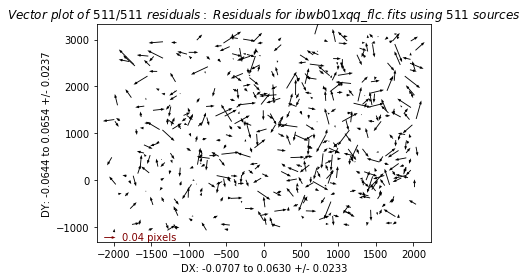

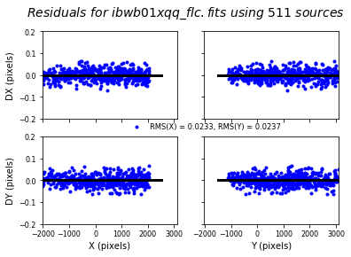

```python
refcat = 'gaia.cat'
cw = 3.5  # Set to two times the FWHM of the PSF.
wcsname = 'Gaia'  # Specify the WCS name for this alignment

tweakreg.TweakReg('*flc.fits',  # Pass input images
                  updatehdr=False,  # update header with new WCS solution
                  imagefindcfg={'threshold':500.,'conv_width':cw},  # Detection parameters, threshold varies for different data
                  refcat=refcat,  # Use user supplied catalog (Gaia)
                  interactive=False,
                  see2dplot=False,
                  shiftfile=True,  # Save out shift file (so we can look at shifts later)
                  outshifts='Gaia_shifts.txt',  # name of the shift file
                  wcsname=wcsname,  # Give our WCS a new name
                  reusename=True,
                  sigma=2.3,
                  ylimit=0.2,
                  fitgeometry='general')  # Use the 6 parameter fit
```

We can similarly look at the shift file from alignment to the Gaia catalog:

```python
for line in open('Gaia_shifts.txt').readlines():
    print(line)
```

```
# frame: output

# refimage: shifts_wcs.fits[wcs]

# form: delta

# units: pixels

ibwb01xrq_flc.fits    4.431611  -5.650320    0.004697     1.000084   0.031119  0.043370

ibwb01xxq_flc.fits    4.873349  -4.844949    0.002547     1.000089   0.031686  0.043584

ibwb01xqq_flc.fits    4.486309  -5.669926    0.004667     1.000089   0.023297  0.023652
```

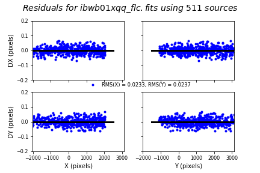

```python
# Astrometric residual plots
Image(filename='residuals_ibwb01xqq_flc.png',width=500, height=300)
```

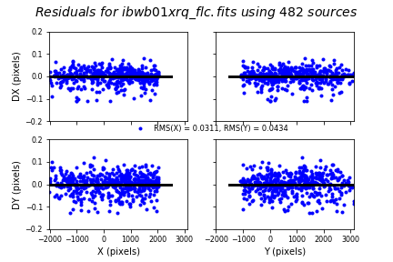

```python
Image(filename='residuals_ibwb01xrq_flc.png',width=500, height=300)
```

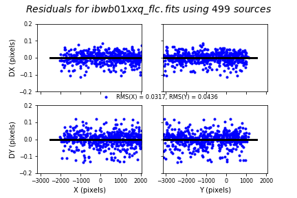

```python
Image(filename='residuals_ibwb01xxq_flc.png',width=500, height=300)
```

As expected, the Gaia catalog does quite a bit better, with rms residuals less tha 0.05 pixels.

To apply these transformations to the image, we simply need to run TweakReg the same as before, but set the parameter `updatehdr` equal to `True`:

```
INFO:drizzlepac.util:Setting up logfile :  tweakreg.log
```

```
Setting up logfile :  tweakreg.log
```

```
INFO:drizzlepac.tweakreg:TweakReg Version 1.4.7(18-April-2018) started at: 01:09:28.703 (18/12/2019)
```

```
TweakReg Version 1.4.7(18-April-2018) started at: 01:09:28.703 (18/12/2019)
```

```
INFO:drizzlepac.tweakreg:
```

```
INFO:drizzlepac.util:Version Information
```

```
Version Information
```

```
INFO:drizzlepac.util:--------------------
```

```
INFO:drizzlepac.util:Python Version [Clang 4.0.1 (tags/RELEASE_401/final)]
```

```
Python Version [Clang 4.0.1 (tags/RELEASE_401/final)]
```

```
INFO:drizzlepac.util:3.7.5 (default, Oct 25 2019, 10:52:18)
```

```
3.7.5 (default, Oct 25 2019, 10:52:18)
```

```
INFO:drizzlepac.util:numpy Version -> 1.17.4
```

```
numpy Version -> 1.17.4
```

```
INFO:drizzlepac.util:astropy Version -> 3.2.3
```

```
astropy Version -> 3.2.3
```

```
INFO:drizzlepac.util:stwcs Version -> 1.5.3
```

```
stwcs Version -> 1.5.3
```

[output not shown]

```
INFO:drizzlepac.tweakreg:Finding shifts for:
```

```
Finding shifts for:
```

```
INFO:drizzlepac.tweakreg:    ibwb01xrq_flc.fits
```

```
    ibwb01xrq_flc.fits
```

```
INFO:drizzlepac.tweakreg:    ibwb01xxq_flc.fits
```

```
    ibwb01xxq_flc.fits
```

```
INFO:drizzlepac.tweakreg:    ibwb01xqq_flc.fits
```

```
    ibwb01xqq_flc.fits
```

```
INFO:drizzlepac.tweakreg:
```

[output not shown]

```
===  Source finding for image 'ibwb01xrq_flc.fits':
```

```
INFO:drizzlepac.catalogs:  #  Source finding for 'ibwb01xrq_flc.fits', EXT=('SCI', 1) started at: 01:09:28.853 (18/12/2019)
```

```
  #  Source finding for 'ibwb01xrq_flc.fits', EXT=('SCI', 1) started at: 01:09:28.853 (18/12/2019)
```

```
INFO:drizzlepac.catalogs:   Finding sources using sky sigma = 5.638966
INFO:drizzlepac.catalogs:###Source finding finished at: 01:09:29.656 (18/12/2019)
INFO:drizzlepac.catalogs:     Found 1363 objects.
```

```
     Found 1363 objects.
```

```
INFO:drizzlepac.catalogs:  #  Source finding for 'ibwb01xrq_flc.fits', EXT=('SCI', 2) started at: 01:09:29.720 (18/12/2019)
```

```
  #  Source finding for 'ibwb01xrq_flc.fits', EXT=('SCI', 2) started at: 01:09:29.720 (18/12/2019)
```

```
INFO:drizzlepac.catalogs:   Finding sources using sky sigma = 5.682907
INFO:drizzlepac.catalogs:###Source finding finished at: 01:09:30.510 (18/12/2019)
INFO:drizzlepac.catalogs:     Found 1313 objects.
```

```
     Found 1313 objects.
```

```
INFO:drizzlepac.imgclasses:===  FINAL number of objects in image 'ibwb01xrq_flc.fits': 2676
```

```
===  FINAL number of objects in image 'ibwb01xrq_flc.fits': 2676
```

```
INFO:drizzlepac.imgclasses:
```

```
INFO:drizzlepac.imgclasses:===  Source finding for image 'ibwb01xxq_flc.fits':
```

```
===  Source finding for image 'ibwb01xxq_flc.fits':
```

```
INFO:drizzlepac.catalogs:  #  Source finding for 'ibwb01xxq_flc.fits', EXT=('SCI', 1) started at: 01:09:30.746 (18/12/2019)
```

```
  #  Source finding for 'ibwb01xxq_flc.fits', EXT=('SCI', 1) started at: 01:09:30.746 (18/12/2019)
```

```
INFO:drizzlepac.catalogs:   Finding sources using sky sigma = 4.939314
INFO:drizzlepac.catalogs:###Source finding finished at: 01:09:31.544 (18/12/2019)
INFO:drizzlepac.catalogs:     Found 1836 objects.
```

```
     Found 1836 objects.
```

```
INFO:drizzlepac.catalogs:  #  Source finding for 'ibwb01xxq_flc.fits', EXT=('SCI', 2) started at: 01:09:31.611 (18/12/2019)
```

```
  #  Source finding for 'ibwb01xxq_flc.fits', EXT=('SCI', 2) started at: 01:09:31.611 (18/12/2019)
```

```
INFO:drizzlepac.catalogs:   Finding sources using sky sigma = 4.820505
INFO:drizzlepac.catalogs:###Source finding finished at: 01:09:32.424 (18/12/2019)
INFO:drizzlepac.catalogs:     Found 2008 objects.
```

```
     Found 2008 objects.
```

```
INFO:drizzlepac.imgclasses:===  FINAL number of objects in image 'ibwb01xxq_flc.fits': 3844
```

```
===  FINAL number of objects in image 'ibwb01xxq_flc.fits': 3844
```

```
INFO:drizzlepac.imgclasses:
```

```
INFO:drizzlepac.imgclasses:===  Source finding for image 'ibwb01xqq_flc.fits':
```

```
===  Source finding for image 'ibwb01xqq_flc.fits':
```

```
INFO:drizzlepac.catalogs:  #  Source finding for 'ibwb01xqq_flc.fits', EXT=('SCI', 1) started at: 01:09:32.643 (18/12/2019)
```

```
  #  Source finding for 'ibwb01xqq_flc.fits', EXT=('SCI', 1) started at: 01:09:32.643 (18/12/2019)
```

```
INFO:drizzlepac.catalogs:   Finding sources using sky sigma = 1.846397
INFO:drizzlepac.catalogs:###Source finding finished at: 01:09:33.433 (18/12/2019)
INFO:drizzlepac.catalogs:     Found 1364 objects.
```

```
     Found 1364 objects.
```

```
INFO:drizzlepac.catalogs:  #  Source finding for 'ibwb01xqq_flc.fits', EXT=('SCI', 2) started at: 01:09:33.49 (18/12/2019)
```

```
  #  Source finding for 'ibwb01xqq_flc.fits', EXT=('SCI', 2) started at: 01:09:33.49 (18/12/2019)
```

```
INFO:drizzlepac.catalogs:   Finding sources using sky sigma = 0.389856
INFO:drizzlepac.catalogs:###Source finding finished at: 01:09:34.382 (18/12/2019)
INFO:drizzlepac.catalogs:     Found 2137 objects.
```

```
     Found 2137 objects.
```

```
INFO:drizzlepac.imgclasses:===  FINAL number of objects in image 'ibwb01xqq_flc.fits': 3501
```

```
===  FINAL number of objects in image 'ibwb01xqq_flc.fits': 3501
```

```
INFO:drizzlepac.imgclasses:
```

[output not shown]

```
INFO:drizzlepac.tweakreg:===============================================================
```

```
INFO:drizzlepac.tweakreg:Performing alignment in the projection plane defined by the WCS
```

```
Performing alignment in the projection plane defined by the WCS
```

```
INFO:drizzlepac.tweakreg:derived from 'ibwb01xrq_flc.fits'
```

```
derived from 'ibwb01xrq_flc.fits'
```

```
INFO:drizzlepac.tweakreg:===============================================================
```

```
INFO:drizzlepac.tweakreg:
```

[output not shown]

```
INFO:drizzlepac.tweakreg:====================
```

```
INFO:drizzlepac.tweakreg:Performing fit for: ibwb01xrq_flc.fits
```

```
Performing fit for: ibwb01xrq_flc.fits
```

```
INFO:drizzlepac.tweakreg:
```

```
INFO:drizzlepac.imgclasses:Matching sources from 'ibwb01xrq_flc.fits' with sources from reference catalog 'gaia.cat'
```

```
Matching sources from 'ibwb01xrq_flc.fits' with sources from reference catalog 'gaia.cat'
```

```
INFO:drizzlepac.imgclasses:Computing initial guess for X and Y shifts...
```

```
Computing initial guess for X and Y shifts...
```

```
INFO:drizzlepac.imgclasses:Found initial X and Y shifts of 4.219, -6.289 with significance of 152.3 and 702 matches
```

```
Found initial X and Y shifts of 4.219, -6.289 with significance of 152.3 and 702 matches
```

```
INFO:drizzlepac.imgclasses:Found 619 matches for ibwb01xrq_flc.fits...
```

```
Found 619 matches for ibwb01xrq_flc.fits...
```

```
INFO:drizzlepac.linearfit:Performing "general" fit
INFO:drizzlepac.linearfit:Performing "general" fit
INFO:drizzlepac.linearfit:Performing "general" fit
INFO:drizzlepac.linearfit:Performing "general" fit
INFO:drizzlepac.imgclasses:Computed  general  fit for  ibwb01xrq_flc.fits :
```

```
Computed  general  fit for  ibwb01xrq_flc.fits :
```

```
INFO:drizzlepac.imgclasses:XSH: 4.4316  YSH: -5.6503    PROPER ROT: 0.004696842134
```

```
XSH: 4.4316  YSH: -5.6503    PROPER ROT: 0.004696842134
```

```
INFO:drizzlepac.imgclasses:<ROT>: 0.004696842134  SKEW: 0.0003977742276    ROT_X: 0.004497955021  ROT_Y: 0.004895729248
```

```
<ROT>: 0.004696842134  SKEW: 0.0003977742276    ROT_X: 0.004497955021  ROT_Y: 0.004895729248
```

```
INFO:drizzlepac.imgclasses:<SCALE>: 1.000083549  SCALE_X: 1.000077526  SCALE_Y: 1.000089572
```

```
<SCALE>: 1.000083549  SCALE_X: 1.000077526  SCALE_Y: 1.000089572
```

```
INFO:drizzlepac.imgclasses:FIT XRMS: 0.031      FIT YRMS: 0.043
```

```
FIT XRMS: 0.031      FIT YRMS: 0.043
```

```
INFO:drizzlepac.imgclasses:FIT RMSE: 0.053      FIT MAE: 0.044
```

```
FIT RMSE: 0.053      FIT MAE: 0.044
```

```
INFO:drizzlepac.imgclasses:
```

```
INFO:drizzlepac.imgclasses:RMS_RA: 7.4e-07 (deg)   RMS_DEC: 1.7e-08 (deg)
```

```
RMS_RA: 7.4e-07 (deg)   RMS_DEC: 1.7e-08 (deg)
```

```
INFO:drizzlepac.imgclasses:
```

```
INFO:drizzlepac.imgclasses:Final solution based on  482  objects.
```

```
Final solution based on  482  objects.
```

```
INFO:drizzlepac.imgclasses:Creating catalog for the fit: ibwb01xrq_flc_catalog_fit.match
INFO:drizzlepac.tweakutils:wrote XY data to:  ibwb01xrq_flc_catalog_fit.match
```

```
wrote XY data to:  ibwb01xrq_flc_catalog_fit.match
```

```
INFO:drizzlepac.tweakutils:Total # points: 482
```

```
Total # points: 482
```

```
INFO:drizzlepac.tweakutils:# of points after clipping: 482
```

```
# of points after clipping: 482
```

```
INFO:drizzlepac.tweakutils:Total # points: 482
```

```
Total # points: 482
```

```
INFO:drizzlepac.tweakutils:# of points after clipping: 482
```

```
# of points after clipping: 482
```

```
INFO:drizzlepac.updatehdr:
```

```
INFO:drizzlepac.updatehdr:....Updating header for ibwb01xrq_flc.fits...
```

```
....Updating header for ibwb01xrq_flc.fits...
```

```
INFO:drizzlepac.updatehdr:
```

```
INFO:drizzlepac.updatehdr:
```

```
INFO:drizzlepac.updatehdr:Processing ibwb01xrq_flc.fits['SCI',1]
```

```
Processing ibwb01xrq_flc.fits['SCI',1]
```

```
INFO:drizzlepac.updatehdr:
```

```
INFO:drizzlepac.updatehdr:Updating header for ibwb01xrq_flc.fits[1]
```

```
Updating header for ibwb01xrq_flc.fits[1]
```

```
INFO:drizzlepac.updatehdr:    with WCS of
INFO:stwcs.wcsutil.hstwcs:WCS Keywords
```

```
WCS Keywords
```

```
INFO:stwcs.wcsutil.hstwcs:
```

```
INFO:stwcs.wcsutil.hstwcs:CD_11  CD_12: -6.71445258969271e-06 -9.202521523942143e-06
```

```
CD_11  CD_12: -6.71445258969271e-06 -9.202521523942143e-06
```

```
INFO:stwcs.wcsutil.hstwcs:CD_21  CD_22: -8.798359582223624e-06 6.145270546221497e-06
```

```
CD_21  CD_22: -8.798359582223624e-06 6.145270546221497e-06
```

```
INFO:stwcs.wcsutil.hstwcs:CRVAL    : 290.23990176450815 37.794734765055225
```

```
CRVAL    : 290.23990176450815 37.794734765055225
```

```
INFO:stwcs.wcsutil.hstwcs:CRPIX    : 2048.0 1026.0
```

```
CRPIX    : 2048.0 1026.0
```

```
INFO:stwcs.wcsutil.hstwcs:NAXIS    : 4096 2051
```

```
NAXIS    : 4096 2051
```

```
INFO:stwcs.wcsutil.hstwcs:Plate Scale : 0.0398469929515555
```

```
Plate Scale : 0.0398469929515555
```

```
INFO:stwcs.wcsutil.hstwcs:ORIENTAT : -56.26574716711297
```

```
ORIENTAT : -56.26574716711297
```

```
INFO:drizzlepac.updatehdr:WCSNAME  :  Gaia
```

```
WCSNAME  :  Gaia
```

```
INFO:drizzlepac.updatehdr:
```

```
INFO:drizzlepac.updatehdr:Processing ibwb01xrq_flc.fits['SCI',2]
```

```
Processing ibwb01xrq_flc.fits['SCI',2]
```

```
INFO:drizzlepac.updatehdr:
```

```
INFO:drizzlepac.updatehdr:Updating header for ibwb01xrq_flc.fits[4]
```

```
Updating header for ibwb01xrq_flc.fits[4]
```

```
INFO:drizzlepac.updatehdr:    with WCS of
INFO:stwcs.wcsutil.hstwcs:WCS Keywords
```

```
WCS Keywords
```

```
INFO:stwcs.wcsutil.hstwcs:
```

```
INFO:stwcs.wcsutil.hstwcs:CD_11  CD_12: -6.731537958587623e-06 -9.088404543083897e-06
```

```
CD_11  CD_12: -6.731537958587623e-06 -9.088404543083897e-06
```

```
INFO:stwcs.wcsutil.hstwcs:CD_21  CD_22: -8.708107846222823e-06 6.080741878779698e-06
```

```
CD_21  CD_22: -8.708107846222823e-06 6.080741878779698e-06
```

```
INFO:stwcs.wcsutil.hstwcs:CRVAL    : 290.21581127760504 37.80746922469125
```

```
CRVAL    : 290.21581127760504 37.80746922469125
```

```
INFO:stwcs.wcsutil.hstwcs:CRPIX    : 2048.0 1026.0
```

```
CRPIX    : 2048.0 1026.0
```

```
INFO:stwcs.wcsutil.hstwcs:NAXIS    : 4096 2051
```

```
NAXIS    : 4096 2051
```

```
INFO:stwcs.wcsutil.hstwcs:Plate Scale : 0.03962677037287118
```

```
Plate Scale : 0.03962677037287118
```

```
INFO:stwcs.wcsutil.hstwcs:ORIENTAT : -56.214867732508935
```

```
ORIENTAT : -56.214867732508935
```

```
INFO:drizzlepac.updatehdr:WCSNAME  :  Gaia
```

```
WCSNAME  :  Gaia
```

```
INFO:drizzlepac.imgclasses:    Writing out new WCS to alternate WCS: "B"
INFO:drizzlepac.imgclasses:Updating WCSCORR table with new WCS solution "Gaia"


INFO:drizzlepac.tweakreg:
```

```
INFO:drizzlepac.tweakreg:====================
```

```
INFO:drizzlepac.tweakreg:Performing fit for: ibwb01xxq_flc.fits
```

```
Performing fit for: ibwb01xxq_flc.fits
```

```
INFO:drizzlepac.tweakreg:
```

```
INFO:drizzlepac.imgclasses:Matching sources from 'ibwb01xxq_flc.fits' with sources from reference catalog 'gaia.cat'
```

```
Matching sources from 'ibwb01xxq_flc.fits' with sources from reference catalog 'gaia.cat'
```

```
INFO:drizzlepac.imgclasses:Computing initial guess for X and Y shifts...
```

```
Computing initial guess for X and Y shifts...
```

```
INFO:drizzlepac.imgclasses:Found initial X and Y shifts of 4.771, -5.298 with significance of 530.9 and 664 matches
```

```
Found initial X and Y shifts of 4.771, -5.298 with significance of 530.9 and 664 matches
```

```
INFO:drizzlepac.imgclasses:Found 650 matches for ibwb01xxq_flc.fits...
```

```
Found 650 matches for ibwb01xxq_flc.fits...
```

```
INFO:drizzlepac.linearfit:Performing "general" fit
INFO:drizzlepac.linearfit:Performing "general" fit
INFO:drizzlepac.linearfit:Performing "general" fit
INFO:drizzlepac.linearfit:Performing "general" fit
INFO:drizzlepac.imgclasses:Computed  general  fit for  ibwb01xxq_flc.fits :
```

```
Computed  general  fit for  ibwb01xxq_flc.fits :
```

```
INFO:drizzlepac.imgclasses:XSH: 4.8733  YSH: -4.8449    PROPER ROT: 0.002547034177
```

```
XSH: 4.8733  YSH: -4.8449    PROPER ROT: 0.002547034177
```

```
INFO:drizzlepac.imgclasses:<ROT>: 0.002547034177  SKEW: 0.0002067280755    ROT_X: 0.002443670139  ROT_Y: 0.002650398214
```

```
<ROT>: 0.002547034177  SKEW: 0.0002067280755    ROT_X: 0.002443670139  ROT_Y: 0.002650398214
```

```
INFO:drizzlepac.imgclasses:<SCALE>: 1.000088774  SCALE_X: 1.000080014  SCALE_Y: 1.000097534
```

```
<SCALE>: 1.000088774  SCALE_X: 1.000080014  SCALE_Y: 1.000097534
```

```
INFO:drizzlepac.imgclasses:FIT XRMS: 0.032      FIT YRMS: 0.044
```

```
FIT XRMS: 0.032      FIT YRMS: 0.044
```

```
INFO:drizzlepac.imgclasses:FIT RMSE: 0.054      FIT MAE: 0.045
```

```
FIT RMSE: 0.054      FIT MAE: 0.045
```

```
INFO:drizzlepac.imgclasses:
```

```
INFO:drizzlepac.imgclasses:RMS_RA: 7.5e-07 (deg)   RMS_DEC: 2.1e-08 (deg)
```

```
RMS_RA: 7.5e-07 (deg)   RMS_DEC: 2.1e-08 (deg)
```

```
INFO:drizzlepac.imgclasses:
```

```
INFO:drizzlepac.imgclasses:Final solution based on  499  objects.
```

```
Final solution based on  499  objects.
```

```
INFO:drizzlepac.imgclasses:Creating catalog for the fit: ibwb01xxq_flc_catalog_fit.match
INFO:drizzlepac.tweakutils:wrote XY data to:  ibwb01xxq_flc_catalog_fit.match
```

```
wrote XY data to:  ibwb01xxq_flc_catalog_fit.match
```

```
INFO:drizzlepac.tweakutils:Total # points: 499
```

```
Total # points: 499
```

```
INFO:drizzlepac.tweakutils:# of points after clipping: 499
```

```
# of points after clipping: 499
```

```
INFO:drizzlepac.tweakutils:Total # points: 499
```

```
Total # points: 499
```

```
INFO:drizzlepac.tweakutils:# of points after clipping: 499
```

```
# of points after clipping: 499
```

```
INFO:drizzlepac.updatehdr:
```

```
INFO:drizzlepac.updatehdr:....Updating header for ibwb01xxq_flc.fits...
```

```
....Updating header for ibwb01xxq_flc.fits...
```

```
INFO:drizzlepac.updatehdr:
```

```
INFO:drizzlepac.updatehdr:
```

```
INFO:drizzlepac.updatehdr:Processing ibwb01xxq_flc.fits['SCI',1]
```

```
Processing ibwb01xxq_flc.fits['SCI',1]
```

```
INFO:drizzlepac.updatehdr:
```

```
INFO:drizzlepac.updatehdr:Updating header for ibwb01xxq_flc.fits[1]
```

```
Updating header for ibwb01xxq_flc.fits[1]
```

```
INFO:drizzlepac.updatehdr:    with WCS of
INFO:stwcs.wcsutil.hstwcs:WCS Keywords
```

```
WCS Keywords
```

```
INFO:stwcs.wcsutil.hstwcs:
```

```
INFO:stwcs.wcsutil.hstwcs:CD_11  CD_12: -6.716394206084726e-06 -9.201163357434026e-06
```

```
CD_11  CD_12: -6.716394206084726e-06 -9.201163357434026e-06
```

```
INFO:stwcs.wcsutil.hstwcs:CD_21  CD_22: -8.796909096901962e-06 6.147236905360251e-06
```

```
CD_21  CD_22: -8.796909096901962e-06 6.147236905360251e-06
```

```
INFO:stwcs.wcsutil.hstwcs:CRVAL    : 290.2637400533991 37.78211827194002
```

```
CRVAL    : 290.2637400533991 37.78211827194002
```

```
INFO:stwcs.wcsutil.hstwcs:CRPIX    : 2048.0 1026.0
```

```
CRPIX    : 2048.0 1026.0
```

```
INFO:stwcs.wcsutil.hstwcs:NAXIS    : 4096 2051
```

```
NAXIS    : 4096 2051
```

```
INFO:stwcs.wcsutil.hstwcs:Plate Scale : 0.039847175433057117
```

```
Plate Scale : 0.039847175433057117
```

```
INFO:stwcs.wcsutil.hstwcs:ORIENTAT : -56.25337479294362
```

```
ORIENTAT : -56.25337479294362
```

```
INFO:drizzlepac.updatehdr:WCSNAME  :  Gaia
```

```
WCSNAME  :  Gaia
```

```
INFO:drizzlepac.updatehdr:
```

```
INFO:drizzlepac.updatehdr:Processing ibwb01xxq_flc.fits['SCI',2]
```

```
Processing ibwb01xxq_flc.fits['SCI',2]
```

```
INFO:drizzlepac.updatehdr:
```

```
INFO:drizzlepac.updatehdr:Updating header for ibwb01xxq_flc.fits[4]
```

```
Updating header for ibwb01xxq_flc.fits[4]
```

```
INFO:drizzlepac.updatehdr:    with WCS of
INFO:stwcs.wcsutil.hstwcs:WCS Keywords
```

```
WCS Keywords
```

```
INFO:stwcs.wcsutil.hstwcs:
```

```
INFO:stwcs.wcsutil.hstwcs:CD_11  CD_12: -6.7334609946725575e-06 -9.08705963848591e-06
```

```
CD_11  CD_12: -6.7334609946725575e-06 -9.08705963848591e-06
```

```
INFO:stwcs.wcsutil.hstwcs:CD_21  CD_22: -8.706652781523419e-06 6.0826852867994225e-06
```

```
CD_21  CD_22: -8.706652781523419e-06 6.0826852867994225e-06
```

```
INFO:stwcs.wcsutil.hstwcs:CRVAL    : 290.2396572421327 37.79485680034623
```

```
CRVAL    : 290.2396572421327 37.79485680034623
```

```
INFO:stwcs.wcsutil.hstwcs:CRPIX    : 2048.0 1026.0
```

```
CRPIX    : 2048.0 1026.0
```

```
INFO:stwcs.wcsutil.hstwcs:NAXIS    : 4096 2051
```

```
NAXIS    : 4096 2051
```

```
INFO:stwcs.wcsutil.hstwcs:Plate Scale : 0.039626951860556925
```

```
Plate Scale : 0.039626951860556925
```

```
INFO:stwcs.wcsutil.hstwcs:ORIENTAT : -56.20248586073764
```

```
ORIENTAT : -56.20248586073764
```

```
INFO:drizzlepac.updatehdr:WCSNAME  :  Gaia
```

```
WCSNAME  :  Gaia
```

```
INFO:drizzlepac.imgclasses:    Writing out new WCS to alternate WCS: "B"
INFO:drizzlepac.imgclasses:Updating WCSCORR table with new WCS solution "Gaia"


INFO:drizzlepac.tweakreg:
```

```
INFO:drizzlepac.tweakreg:====================
```

```
INFO:drizzlepac.tweakreg:Performing fit for: ibwb01xqq_flc.fits
```

```
Performing fit for: ibwb01xqq_flc.fits
```

```
INFO:drizzlepac.tweakreg:
```

```
INFO:drizzlepac.imgclasses:Matching sources from 'ibwb01xqq_flc.fits' with sources from reference catalog 'gaia.cat'
```

```
Matching sources from 'ibwb01xqq_flc.fits' with sources from reference catalog 'gaia.cat'
```

```
INFO:drizzlepac.imgclasses:Computing initial guess for X and Y shifts...
```

```
Computing initial guess for X and Y shifts...
```

```
INFO:drizzlepac.imgclasses:Found initial X and Y shifts of 4.694, -5.962 with significance of 136.9 and 648 matches
```

```
Found initial X and Y shifts of 4.694, -5.962 with significance of 136.9 and 648 matches
```

```
INFO:drizzlepac.imgclasses:Found 631 matches for ibwb01xqq_flc.fits...
```

```
Found 631 matches for ibwb01xqq_flc.fits...
```

```
INFO:drizzlepac.linearfit:Performing "general" fit
INFO:drizzlepac.linearfit:Performing "general" fit
INFO:drizzlepac.linearfit:Performing "general" fit
INFO:drizzlepac.linearfit:Performing "general" fit
INFO:drizzlepac.imgclasses:Computed  general  fit for  ibwb01xqq_flc.fits :
```

```
Computed  general  fit for  ibwb01xqq_flc.fits :
```

```
INFO:drizzlepac.imgclasses:XSH: 4.4863  YSH: -5.6699    PROPER ROT: 0.00466747289
```

```
XSH: 4.4863  YSH: -5.6699    PROPER ROT: 0.00466747289
```

```
INFO:drizzlepac.imgclasses:<ROT>: 0.00466747289  SKEW: 0.0003347041837    ROT_X: 0.004500120798  ROT_Y: 0.004834824982
```

```
<ROT>: 0.00466747289  SKEW: 0.0003347041837    ROT_X: 0.004500120798  ROT_Y: 0.004834824982
```

```
INFO:drizzlepac.imgclasses:<SCALE>: 1.000088602  SCALE_X: 1.000080279  SCALE_Y: 1.000096925
```

```
<SCALE>: 1.000088602  SCALE_X: 1.000080279  SCALE_Y: 1.000096925
```

```
INFO:drizzlepac.imgclasses:FIT XRMS: 0.023      FIT YRMS: 0.024
```

```
FIT XRMS: 0.023      FIT YRMS: 0.024
```

```
INFO:drizzlepac.imgclasses:FIT RMSE: 0.033      FIT MAE: 0.029
```

```
FIT RMSE: 0.033      FIT MAE: 0.029
```

```
INFO:drizzlepac.imgclasses:
```

```
INFO:drizzlepac.imgclasses:RMS_RA: 4.5e-07 (deg)   RMS_DEC: 6.7e-08 (deg)
```

```
RMS_RA: 4.5e-07 (deg)   RMS_DEC: 6.7e-08 (deg)
```

```
INFO:drizzlepac.imgclasses:
```

```
INFO:drizzlepac.imgclasses:Final solution based on  511  objects.
```

```
Final solution based on  511  objects.
```

```
INFO:drizzlepac.imgclasses:Creating catalog for the fit: ibwb01xqq_flc_catalog_fit.match
INFO:drizzlepac.tweakutils:wrote XY data to:  ibwb01xqq_flc_catalog_fit.match
```

```
wrote XY data to:  ibwb01xqq_flc_catalog_fit.match
```

```
INFO:drizzlepac.tweakutils:Total # points: 511
```

```
Total # points: 511
```

```
INFO:drizzlepac.tweakutils:# of points after clipping: 511
```

```
# of points after clipping: 511
```

```
INFO:drizzlepac.tweakutils:Total # points: 511
```

```
Total # points: 511
```

```
INFO:drizzlepac.tweakutils:# of points after clipping: 511
```

```
# of points after clipping: 511
```

```
INFO:drizzlepac.updatehdr:
```

```
INFO:drizzlepac.updatehdr:....Updating header for ibwb01xqq_flc.fits...
```

```
....Updating header for ibwb01xqq_flc.fits...
```

```
INFO:drizzlepac.updatehdr:
```

```
INFO:drizzlepac.updatehdr:
```

```
INFO:drizzlepac.updatehdr:Processing ibwb01xqq_flc.fits['SCI',1]
```

```
Processing ibwb01xqq_flc.fits['SCI',1]
```

```
INFO:drizzlepac.updatehdr:
```

```
INFO:drizzlepac.updatehdr:Updating header for ibwb01xqq_flc.fits[1]
```

```
Updating header for ibwb01xqq_flc.fits[1]
```

```
INFO:drizzlepac.updatehdr:    with WCS of
INFO:stwcs.wcsutil.hstwcs:WCS Keywords
```

```
WCS Keywords
```

```
INFO:stwcs.wcsutil.hstwcs:
```

```
INFO:stwcs.wcsutil.hstwcs:CD_11  CD_12: -6.714434251226519e-06 -9.202463117195532e-06
```

```
CD_11  CD_12: -6.714434251226519e-06 -9.202463117195532e-06
```

```
INFO:stwcs.wcsutil.hstwcs:CD_21  CD_22: -8.798339810055961e-06 6.14521716896683e-06
```

```
CD_21  CD_22: -8.798339810055961e-06 6.14521716896683e-06
```

```
INFO:stwcs.wcsutil.hstwcs:CRVAL    : 290.2399019631409 37.79473538497346
```

```
CRVAL    : 290.2399019631409 37.79473538497346
```

```
INFO:stwcs.wcsutil.hstwcs:CRPIX    : 2048.0 1026.0
```

```
CRPIX    : 2048.0 1026.0
```

```
INFO:stwcs.wcsutil.hstwcs:NAXIS    : 4096 2051
```

```
NAXIS    : 4096 2051
```

```
INFO:stwcs.wcsutil.hstwcs:Plate Scale : 0.039847004058886186
```

```
Plate Scale : 0.039847004058886186
```

```
INFO:stwcs.wcsutil.hstwcs:ORIENTAT : -56.265809062556215
```

```
ORIENTAT : -56.265809062556215
```

```
INFO:drizzlepac.updatehdr:WCSNAME  :  Gaia
```

```
WCSNAME  :  Gaia
```

```
INFO:drizzlepac.updatehdr:
```

```
INFO:drizzlepac.updatehdr:Processing ibwb01xqq_flc.fits['SCI',2]
```

```
Processing ibwb01xqq_flc.fits['SCI',2]
```

```
INFO:drizzlepac.updatehdr:
```

```
INFO:drizzlepac.updatehdr:Updating header for ibwb01xqq_flc.fits[4]
```

```
Updating header for ibwb01xqq_flc.fits[4]
```

```
INFO:drizzlepac.updatehdr:    with WCS of
INFO:stwcs.wcsutil.hstwcs:WCS Keywords
```

```
WCS Keywords
```

```
INFO:stwcs.wcsutil.hstwcs:
```

```
INFO:stwcs.wcsutil.hstwcs:CD_11  CD_12: -6.731519378880771e-06 -9.088346820564065e-06
```

```
CD_11  CD_12: -6.731519378880771e-06 -9.088346820564065e-06
```

```
INFO:stwcs.wcsutil.hstwcs:CD_21  CD_22: -8.708088524976063e-06 6.080689133240222e-06
```

```
CD_21  CD_22: -8.708088524976063e-06 6.080689133240222e-06
```

```
INFO:stwcs.wcsutil.hstwcs:CRVAL    : 290.2158116290336 37.807469734112615
```

```
CRVAL    : 290.2158116290336 37.807469734112615
```

```
INFO:stwcs.wcsutil.hstwcs:CRPIX    : 2048.0 1026.0
```

```
CRPIX    : 2048.0 1026.0
```

```
INFO:stwcs.wcsutil.hstwcs:NAXIS    : 4096 2051
```

```
NAXIS    : 4096 2051
```

```
INFO:stwcs.wcsutil.hstwcs:Plate Scale : 0.03962678141881469
```

```
Plate Scale : 0.03962678141881469
```

```
INFO:stwcs.wcsutil.hstwcs:ORIENTAT : -56.21492924658077
```

```
ORIENTAT : -56.21492924658077
```

```
INFO:drizzlepac.updatehdr:WCSNAME  :  Gaia
```

```
WCSNAME  :  Gaia
```

```
INFO:drizzlepac.imgclasses:    Writing out new WCS to alternate WCS: "B"
INFO:drizzlepac.imgclasses:Updating WCSCORR table with new WCS solution "Gaia"


INFO:drizzlepac.tweakutils:Writing out shiftfile : Gaia_shifts.txt
```

```
Writing out shiftfile : Gaia_shifts.txt
```

```
INFO:drizzlepac.util:Trailer file written to:  tweakreg.log
```

```
Trailer file written to:  tweakreg.log
```

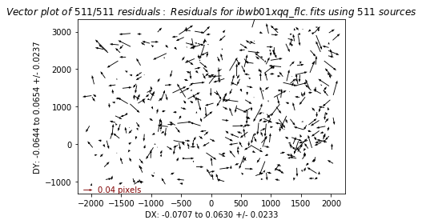

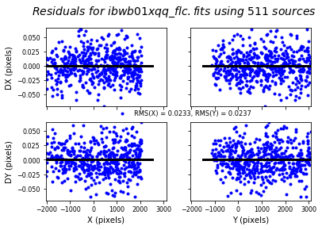

```python
refcat = 'gaia.cat'
cw = 3.5  # Set to two times the FWHM of the PSF.
wcsname = 'Gaia'  # Specify the WCS name for this alignment

tweakreg.TweakReg('*flc.fits',  # Pass input images
                  updatehdr=True,  # update header with new WCS solution
                  imagefindcfg={'threshold': 500., 'conv_width': cw},  # Detection parameters, threshold varies for different data
                  refcat=refcat,  # Use user supplied catalog (Gaia)
                  interactive=False,
                  see2dplot=False,
                  shiftfile=True,  # Save out shift file (so we can look at shifts later)
                  outshifts='Gaia_shifts.txt',  # name of the shift file
                  wcsname=wcsname,  # Give our WCS a new name
                  reusename=True,
                  sigma=2.3,
                  fitgeometry='general')  # Use the 6 parameter fit
```

## 4. Drizzle the Data

While the three sets of FLC files are now aligned, we drizzle together only the two long exposures.

When exposures are very different lengths, drizzling them together doesn't work well when 'EXP' weighting is used. For objects that saturate in the long exposures, the problem occurs at the boundary where you transition from only short exposure to short plus long. Here the pixels getting power from long exposure pixels are only getting power from pixels whose centers are outside the ring, and thus they are weighted lower than they would be if they were getting values from both inside and outside the ring. The result is a discontinuity in the PSF radial profile and a resulting flux which is too low in those boundary pixels. For photometry of saturated objects, the short exposures should be drizzled separately from the long exposures.

```python
astrodrizzle.AstroDrizzle('ibwb01x[rx]q_flc.fits',
                          output='f606w',
                          preserve=False,
                          clean=True,
                          build=False,
                          context=False,
                          skymethod='match',
                          driz_sep_bits='64, 32',
                          combine_type='minmed',
                          final_bits='64, 32')
```

```
INFO:drizzlepac.util:Setting up logfile :  astrodrizzle.log
```

```
Setting up logfile :  astrodrizzle.log
```

```
INFO:drizzlepac.astrodrizzle:AstroDrizzle Version 3.1.3 (2019-11-06 14:37:50 -0500) started at: 01:09:39.699 (18/12/2019)
```

```
AstroDrizzle Version 3.1.3 (2019-11-06 14:37:50 -0500) started at: 01:09:39.699 (18/12/2019)
```

```
INFO:drizzlepac.astrodrizzle:
```

```
INFO:drizzlepac.astrodrizzle:Version Information
INFO:drizzlepac.astrodrizzle:--------------------
INFO:drizzlepac.astrodrizzle:Python Version [Clang 4.0.1 (tags/RELEASE_401/final)]
INFO:drizzlepac.astrodrizzle:3.7.5 (default, Oct 25 2019, 10:52:18)
INFO:drizzlepac.astrodrizzle:numpy Version -> 1.17.4
INFO:drizzlepac.astrodrizzle:astropy Version -> 3.2.3
INFO:drizzlepac.astrodrizzle:stwcs Version -> 1.5.3
INFO:drizzlepac.util:==== Processing Step  Initialization  started at  01:09:39.7 (18/12/2019)
```

```
==== Processing Step  Initialization  started at  01:09:39.7 (18/12/2019)
```

[output not shown]

```
WCS Keywords
```

```
INFO:astropy.wcs.wcs:
```

```
INFO:astropy.wcs.wcs:Number of WCS axes: 2
```

```
Number of WCS axes: 2
```

```
INFO:astropy.wcs.wcs:CTYPE : 'RA---TAN'  'DEC--TAN'
```

```
CTYPE : 'RA---TAN'  'DEC--TAN'
```

```
INFO:astropy.wcs.wcs:CRVAL : 290.2397215117102  37.79477401246605
```

```
CRVAL : 290.2397215117102  37.79477401246605
```

```
INFO:astropy.wcs.wcs:CRPIX : 2065.5  3222.5
```

```
CRPIX : 2065.5  3222.5
```

```
INFO:astropy.wcs.wcs:CD1_1 CD1_2  : -6.1512273393101596e-06  -9.126042988064386e-06
```

```
CD1_1 CD1_2  : -6.1512273393101596e-06  -9.126042988064386e-06
```

```
INFO:astropy.wcs.wcs:CD2_1 CD2_2  : -9.126042988064386e-06  6.1512273393101596e-06
```

```
CD2_1 CD2_2  : -9.126042988064386e-06  6.1512273393101596e-06
```

```
INFO:astropy.wcs.wcs:NAXIS : 4131  6445
```

```
NAXIS : 4131  6445
```

```
INFO:drizzlepac.processInput:********************************************************************************
```

```
INFO:drizzlepac.processInput:*
```

```
INFO:drizzlepac.processInput:*  Estimated memory usage:  up to 1475 Mb.
```

```
*  Estimated memory usage:  up to 1475 Mb.
```

```
INFO:drizzlepac.processInput:*  Output image size:       4131 X 6445 pixels.
```

```
*  Output image size:       4131 X 6445 pixels.
```

```
INFO:drizzlepac.processInput:*  Output image file:       ~ 304 Mb.
```

```
*  Output image file:       ~ 304 Mb.
```

```
INFO:drizzlepac.processInput:*  Cores available:         4
```

```
*  Cores available:         4
```

```
INFO:drizzlepac.processInput:*
```

```
INFO:drizzlepac.processInput:********************************************************************************
```

```
INFO:drizzlepac.util:==== Processing Step  Initialization  finished at  01:09:40.414 (18/12/2019)
```

```
==== Processing Step  Initialization  finished at  01:09:40.414 (18/12/2019)
```

```
INFO:drizzlepac.util:
```

[output not shown]

```
==== Processing Step  Static Mask  started at  01:09:40.423 (18/12/2019)
```

[output not shown]

```
==== Processing Step  Static Mask  finished at  01:09:41.295 (18/12/2019)
```

```
INFO:drizzlepac.util:
```

```
INFO:drizzlepac.util:==== Processing Step  Subtract Sky  started at  01:09:41.297 (18/12/2019)
```

```
==== Processing Step  Subtract Sky  started at  01:09:41.297 (18/12/2019)
```

[output not shown]

```
***** skymatch started on 2019-12-18 01:09:41.532481
```

```
INFO:stsci.skypac.utils:      Version 1.0.4 (2019-05-30 14:31:23 -0400)
```

```
      Version 1.0.4 (2019-05-30 14:31:23 -0400)
```

```
INFO:stsci.skypac.utils:
```

```
INFO:stsci.skypac.utils:'skymatch' task will apply computed sky differences to input image file(s).
```

```
'skymatch' task will apply computed sky differences to input image file(s).
```

```
INFO:stsci.skypac.utils:
```

```
INFO:stsci.skypac.utils:NOTE: Computed sky values WILL NOT be subtracted from image data ('subtractsky'=False).
```

```
NOTE: Computed sky values WILL NOT be subtracted from image data ('subtractsky'=False).
```

```
INFO:stsci.skypac.utils:'MDRIZSKY' header keyword will represent sky value *computed* from data.
```

```
'MDRIZSKY' header keyword will represent sky value *computed* from data.
```

```
INFO:stsci.skypac.utils:
```

```
INFO:stsci.skypac.utils:-----  User specified keywords:  -----
```

```
-----  User specified keywords:  -----
```

```
INFO:stsci.skypac.utils:       Sky Value Keyword:  'MDRIZSKY'
```

```
       Sky Value Keyword:  'MDRIZSKY'
```

```
INFO:stsci.skypac.utils:       Data Units Keyword: 'BUNIT'
```

```
       Data Units Keyword: 'BUNIT'
```

```
INFO:stsci.skypac.utils:
```

```
INFO:stsci.skypac.utils:
```

```
INFO:stsci.skypac.utils:-----  Input file list:  -----
```

```
-----  Input file list:  -----
```

```
INFO:stsci.skypac.utils:
```

```
INFO:stsci.skypac.utils:   **  Input image: 'ibwb01xrq_flc.fits'
```

```
   **  Input image: 'ibwb01xrq_flc.fits'
```

```
INFO:stsci.skypac.utils:       EXT: 'SCI',1;	MASK: ibwb01xrq_skymatch_mask_sci1.fits[0]
```

```
       EXT: 'SCI',1;	MASK: ibwb01xrq_skymatch_mask_sci1.fits[0]
```

```
INFO:stsci.skypac.utils:       EXT: 'SCI',2;	MASK: ibwb01xrq_skymatch_mask_sci2.fits[0]
```

```
       EXT: 'SCI',2;	MASK: ibwb01xrq_skymatch_mask_sci2.fits[0]
```

```
INFO:stsci.skypac.utils:
```

```
INFO:stsci.skypac.utils:   **  Input image: 'ibwb01xxq_flc.fits'
```

```
   **  Input image: 'ibwb01xxq_flc.fits'
```

```
INFO:stsci.skypac.utils:       EXT: 'SCI',1;	MASK: ibwb01xxq_skymatch_mask_sci1.fits[0]
```

```
       EXT: 'SCI',1;	MASK: ibwb01xxq_skymatch_mask_sci1.fits[0]
```

```
INFO:stsci.skypac.utils:       EXT: 'SCI',2;	MASK: ibwb01xxq_skymatch_mask_sci2.fits[0]
```

```
       EXT: 'SCI',2;	MASK: ibwb01xxq_skymatch_mask_sci2.fits[0]
```

```
INFO:stsci.skypac.utils:
```

```
INFO:stsci.skypac.utils:-----  Sky statistics parameters:  -----
```

```
-----  Sky statistics parameters:  -----
```

```
INFO:stsci.skypac.utils:       statistics function: 'median'
```

```
       statistics function: 'median'
```

```
INFO:stsci.skypac.utils:       lower = None
```

```
       lower = None
```

```
INFO:stsci.skypac.utils:       upper = None
```

```
       upper = None
```

```
INFO:stsci.skypac.utils:       nclip = 5
```

```
       nclip = 5
```

```
INFO:stsci.skypac.utils:       lsigma = 4.0
```

```
       lsigma = 4.0
```

```
INFO:stsci.skypac.utils:       usigma = 4.0
```

```
       usigma = 4.0
```

```
INFO:stsci.skypac.utils:       binwidth = 0.1
```

```
       binwidth = 0.1
```

```
INFO:stsci.skypac.utils:
```

```
INFO:stsci.skypac.utils:-----  Data->Brightness conversion parameters for input files:  -----
```

```
-----  Data->Brightness conversion parameters for input files:  -----
```

```
INFO:stsci.skypac.utils:
```

```
INFO:stsci.skypac.utils:   *   Image: ibwb01xrq_flc.fits
```

```
   *   Image: ibwb01xrq_flc.fits
```

```
INFO:stsci.skypac.utils:       EXT = 'SCI',1
```

```
       EXT = 'SCI',1
```

```
INFO:stsci.skypac.utils:             Data units type: COUNTS
```

```
             Data units type: COUNTS
```

```
INFO:stsci.skypac.utils:             EXPTIME: 360.0 [s]
```

```
             EXPTIME: 360.0 [s]
```

```
INFO:stsci.skypac.utils:             Conversion factor (data->brightness):  1.7695732221887426
```

```
             Conversion factor (data->brightness):  1.7695732221887426
```

```
INFO:stsci.skypac.utils:       EXT = 'SCI',2
```

```
       EXT = 'SCI',2
```

```
INFO:stsci.skypac.utils:             Data units type: COUNTS
```

```
             Data units type: COUNTS
```

```
INFO:stsci.skypac.utils:             EXPTIME: 360.0 [s]
```

```
             EXPTIME: 360.0 [s]
```

```
INFO:stsci.skypac.utils:             Conversion factor (data->brightness):  1.7695732221887426
```

```
             Conversion factor (data->brightness):  1.7695732221887426
```

```
INFO:stsci.skypac.utils:
```

```
INFO:stsci.skypac.utils:   *   Image: ibwb01xxq_flc.fits
```

```
   *   Image: ibwb01xxq_flc.fits
```

```
INFO:stsci.skypac.utils:       EXT = 'SCI',1
```

```
       EXT = 'SCI',1
```

```
INFO:stsci.skypac.utils:             Data units type: COUNTS
```

```
             Data units type: COUNTS
```

```
INFO:stsci.skypac.utils:             EXPTIME: 360.0 [s]
```

```
             EXPTIME: 360.0 [s]
```

```
INFO:stsci.skypac.utils:             Conversion factor (data->brightness):  1.7695732221887426
```

```
             Conversion factor (data->brightness):  1.7695732221887426
```

```
INFO:stsci.skypac.utils:       EXT = 'SCI',2
```

```
       EXT = 'SCI',2
```

```
INFO:stsci.skypac.utils:             Data units type: COUNTS
```

```
             Data units type: COUNTS
```

```
INFO:stsci.skypac.utils:             EXPTIME: 360.0 [s]
```

```
             EXPTIME: 360.0 [s]
```

```
INFO:stsci.skypac.utils:             Conversion factor (data->brightness):  1.7695732221887426
```

```
             Conversion factor (data->brightness):  1.7695732221887426
```

```
INFO:stsci.skypac.utils:
```

```
INFO:stsci.skypac.utils:
```

```
INFO:stsci.skypac.utils:-----  Computing differences in sky values in overlapping regions:  -----
```

```
-----  Computing differences in sky values in overlapping regions:  -----
```

```
INFO:stsci.skypac.utils:
```

```
INFO:stsci.skypac.utils:   *   Image 'ibwb01xrq_flc.fits['SCI',1,2]' SKY = 3.72693 [brightness units]
```

```
   *   Image 'ibwb01xrq_flc.fits['SCI',1,2]' SKY = 3.72693 [brightness units]
```

```
INFO:stsci.skypac.utils:       Updating sky of image extension(s) [data units]:
```

```
       Updating sky of image extension(s) [data units]:
```

```
INFO:stsci.skypac.utils:       -  EXT = 'SCI',1   delta(MDRIZSKY) = 2.10612
```

```
       -  EXT = 'SCI',1   delta(MDRIZSKY) = 2.10612
```

```
INFO:stsci.skypac.utils:       -  EXT = 'SCI',2   delta(MDRIZSKY) = 2.10612
```

```
       -  EXT = 'SCI',2   delta(MDRIZSKY) = 2.10612
```

```
INFO:stsci.skypac.utils:
```

```
INFO:stsci.skypac.utils:   *   Image 'ibwb01xxq_flc.fits['SCI',1,2]' SKY = 0 [brightness units]
```

```
   *   Image 'ibwb01xxq_flc.fits['SCI',1,2]' SKY = 0 [brightness units]
```

```
INFO:stsci.skypac.utils:       Updating sky of image extension(s) [data units]:
```

```
       Updating sky of image extension(s) [data units]:
```

```
INFO:stsci.skypac.utils:       -  EXT = 'SCI',1   delta(MDRIZSKY) = 0
```

```
       -  EXT = 'SCI',1   delta(MDRIZSKY) = 0
```

```
INFO:stsci.skypac.utils:       -  EXT = 'SCI',2   delta(MDRIZSKY) = 0
```

```
       -  EXT = 'SCI',2   delta(MDRIZSKY) = 0
```

```
INFO:stsci.skypac.utils:
```

```
INFO:stsci.skypac.utils:***** skymatch ended on 2019-12-18 01:09:42.914024
```

```
***** skymatch ended on 2019-12-18 01:09:42.914024
```

```
INFO:stsci.skypac.utils:TOTAL RUN TIME: 0:00:01.381543
```

```
TOTAL RUN TIME: 0:00:01.381543
```

```
INFO:drizzlepac.util:==== Processing Step  Subtract Sky  finished at  01:09:43.137 (18/12/2019)
```

```
==== Processing Step  Subtract Sky  finished at  01:09:43.137 (18/12/2019)
```

```
INFO:drizzlepac.util:
```

```
INFO:drizzlepac.util:==== Processing Step  Separate Drizzle  started at  01:09:43.139 (18/12/2019)
```

```
==== Processing Step  Separate Drizzle  started at  01:09:43.139 (18/12/2019)
```

[output not shown]

```
WCS Keywords
```

```
INFO:astropy.wcs.wcs:
```

```
INFO:astropy.wcs.wcs:Number of WCS axes: 2
```

```
Number of WCS axes: 2
```

```
INFO:astropy.wcs.wcs:CTYPE : 'RA---TAN'  'DEC--TAN'
```

```
CTYPE : 'RA---TAN'  'DEC--TAN'
```

```
INFO:astropy.wcs.wcs:CRVAL : 290.2397215117102  37.79477401246605
```

```
CRVAL : 290.2397215117102  37.79477401246605
```

```
INFO:astropy.wcs.wcs:CRPIX : 2065.5  3222.5
```

```
CRPIX : 2065.5  3222.5
```

```
INFO:astropy.wcs.wcs:CD1_1 CD1_2  : -6.1512273393101596e-06  -9.126042988064386e-06
```

```
CD1_1 CD1_2  : -6.1512273393101596e-06  -9.126042988064386e-06
```

```
INFO:astropy.wcs.wcs:CD2_1 CD2_2  : -9.126042988064386e-06  6.1512273393101596e-06
```

```
CD2_1 CD2_2  : -9.126042988064386e-06  6.1512273393101596e-06
```

```
INFO:astropy.wcs.wcs:NAXIS : 4131  6445
```

```
NAXIS : 4131  6445
```

[output not shown]

```
-Generating simple FITS output: ibwb01xrq_single_sci.fits
-Generating simple FITS output: ibwb01xxq_single_sci.fits
```

```
INFO:drizzlepac.outputimage:Writing out image to disk: ibwb01xrq_single_sci.fits
```

```
Writing out image to disk: ibwb01xrq_single_sci.fits
```

```
INFO:drizzlepac.outputimage:Writing out image to disk: ibwb01xxq_single_sci.fits
```

```
Writing out image to disk: ibwb01xxq_single_sci.fits
```

```
INFO:drizzlepac.outputimage:Writing out image to disk: ibwb01xrq_single_wht.fits
```

```
Writing out image to disk: ibwb01xrq_single_wht.fits
```

```
INFO:drizzlepac.outputimage:Writing out image to disk: ibwb01xxq_single_wht.fits
```

```
Writing out image to disk: ibwb01xxq_single_wht.fits
```

```
INFO:drizzlepac.util:==== Processing Step  Separate Drizzle  finished at  01:09:46.753 (18/12/2019)
```

```
==== Processing Step  Separate Drizzle  finished at  01:09:46.753 (18/12/2019)
```

```
INFO:drizzlepac.util:
```

```
INFO:drizzlepac.util:==== Processing Step  Create Median  started at  01:09:46.761 (18/12/2019)
```

```
==== Processing Step  Create Median  started at  01:09:46.761 (18/12/2019)
```

[output not shown]

```
reference sky value for image 'ibwb01xrq_flc.fits' is 2.106119466914264
```

```
INFO:drizzlepac.createMedian:reference sky value for image 'ibwb01xxq_flc.fits' is 0.0
```

```
reference sky value for image 'ibwb01xxq_flc.fits' is 0.0
```

```
INFO:drizzlepac.createMedian:Saving output median image to: 'f606w_med.fits'
```

```
Saving output median image to: 'f606w_med.fits'
```

```
INFO:drizzlepac.util:==== Processing Step  Create Median  finished at  01:09:55.378 (18/12/2019)
```

```
==== Processing Step  Create Median  finished at  01:09:55.378 (18/12/2019)
```

```
INFO:drizzlepac.util:
```

```
INFO:drizzlepac.util:==== Processing Step  Blot  started at  01:09:55.380 (18/12/2019)
```

```
==== Processing Step  Blot  started at  01:09:55.380 (18/12/2019)
```

```
INFO:drizzlepac.ablot:USER INPUT PARAMETERS for Blot Step:
INFO:drizzlepac.ablot:	blot_addsky :	True
INFO:drizzlepac.ablot:	blot_interp :	poly5
INFO:drizzlepac.ablot:	blot_sinscl :	1.0
INFO:drizzlepac.ablot:	blot_skyval :	0.0
INFO:drizzlepac.ablot:	coeffs :	True
INFO:drizzlepac.ablot:    Blot: creating blotted image:  ibwb01xrq_flc.fits[sci,1]
```

```
    Blot: creating blotted image:  ibwb01xrq_flc.fits[sci,1]
```

```
INFO:drizzlepac.ablot:Using default C-based coordinate transformation...
```

```
Using default C-based coordinate transformation...
```

```
INFO:drizzlepac.ablot:Applying sky value of 2.106119 to blotted image ibwb01xrq_flc.fits[sci,1]
INFO:drizzlepac.outputimage:-Generating simple FITS output: ibwb01xrq_sci1_blt.fits
```

```
-Generating simple FITS output: ibwb01xrq_sci1_blt.fits
```

```
INFO:drizzlepac.outputimage:Writing out image to disk: ibwb01xrq_sci1_blt.fits
```

```
Writing out image to disk: ibwb01xrq_sci1_blt.fits
```

```
INFO:drizzlepac.ablot:    Blot: creating blotted image:  ibwb01xrq_flc.fits[sci,2]
```

```
    Blot: creating blotted image:  ibwb01xrq_flc.fits[sci,2]
```

```
INFO:drizzlepac.ablot:Using default C-based coordinate transformation...
```

```
Using default C-based coordinate transformation...
```

```
INFO:drizzlepac.ablot:Applying sky value of 2.106119 to blotted image ibwb01xrq_flc.fits[sci,2]
INFO:drizzlepac.outputimage:-Generating simple FITS output: ibwb01xrq_sci2_blt.fits
```

```
-Generating simple FITS output: ibwb01xrq_sci2_blt.fits
```

```
INFO:drizzlepac.outputimage:Writing out image to disk: ibwb01xrq_sci2_blt.fits
```

```
Writing out image to disk: ibwb01xrq_sci2_blt.fits
```

```
INFO:drizzlepac.ablot:    Blot: creating blotted image:  ibwb01xxq_flc.fits[sci,1]
```

```
    Blot: creating blotted image:  ibwb01xxq_flc.fits[sci,1]
```

```
INFO:drizzlepac.ablot:Using default C-based coordinate transformation...
```

```
Using default C-based coordinate transformation...
```

```
INFO:drizzlepac.ablot:Applying sky value of 0.000000 to blotted image ibwb01xxq_flc.fits[sci,1]
INFO:drizzlepac.outputimage:-Generating simple FITS output: ibwb01xxq_sci1_blt.fits
```

```
-Generating simple FITS output: ibwb01xxq_sci1_blt.fits
```

```
INFO:drizzlepac.outputimage:Writing out image to disk: ibwb01xxq_sci1_blt.fits
```

```
Writing out image to disk: ibwb01xxq_sci1_blt.fits
```

```
INFO:drizzlepac.ablot:    Blot: creating blotted image:  ibwb01xxq_flc.fits[sci,2]
```

```
    Blot: creating blotted image:  ibwb01xxq_flc.fits[sci,2]
```

```
INFO:drizzlepac.ablot:Using default C-based coordinate transformation...
```

```
Using default C-based coordinate transformation...
```

```
INFO:drizzlepac.ablot:Applying sky value of 0.000000 to blotted image ibwb01xxq_flc.fits[sci,2]
INFO:drizzlepac.outputimage:-Generating simple FITS output: ibwb01xxq_sci2_blt.fits
```

```
-Generating simple FITS output: ibwb01xxq_sci2_blt.fits
```

```
INFO:drizzlepac.outputimage:Writing out image to disk: ibwb01xxq_sci2_blt.fits
```

```
Writing out image to disk: ibwb01xxq_sci2_blt.fits
```

```
INFO:drizzlepac.util:==== Processing Step  Blot  finished at  01:10:01.29 (18/12/2019)
```

```
==== Processing Step  Blot  finished at  01:10:01.29 (18/12/2019)
```

```
INFO:drizzlepac.util:
```

```
INFO:drizzlepac.util:==== Processing Step  Driz_CR  started at  01:10:01.298 (18/12/2019)
```

```
==== Processing Step  Driz_CR  started at  01:10:01.298 (18/12/2019)
```

[output not shown]

```
Creating output: ibwb01xrq_sci1_crmask.fits
Creating output: ibwb01xxq_sci1_crmask.fits
```

```
INFO:drizzlepac.drizCR:Creating output: ibwb01xrq_sci2_crmask.fits
```

```
Creating output: ibwb01xrq_sci2_crmask.fits
```

```
INFO:drizzlepac.drizCR:Creating output: ibwb01xxq_sci2_crmask.fits
```

```
Creating output: ibwb01xxq_sci2_crmask.fits
```

```
INFO:drizzlepac.util:==== Processing Step  Driz_CR  finished at  01:10:05.002 (18/12/2019)
```

```
==== Processing Step  Driz_CR  finished at  01:10:05.002 (18/12/2019)
```

```
INFO:drizzlepac.util:
```

```
INFO:drizzlepac.util:==== Processing Step  Final Drizzle  started at  01:10:05.01 (18/12/2019)
```

```
==== Processing Step  Final Drizzle  started at  01:10:05.01 (18/12/2019)
```

[output not shown]

```
WCS Keywords
```

```
INFO:astropy.wcs.wcs:
```

```
INFO:astropy.wcs.wcs:Number of WCS axes: 2
```

```
Number of WCS axes: 2
```

```
INFO:astropy.wcs.wcs:CTYPE : 'RA---TAN'  'DEC--TAN'
```

```
CTYPE : 'RA---TAN'  'DEC--TAN'
```

```
INFO:astropy.wcs.wcs:CRVAL : 290.2397215117102  37.79477401246605
```

```
CRVAL : 290.2397215117102  37.79477401246605
```

```
INFO:astropy.wcs.wcs:CRPIX : 2065.5  3222.5
```

```
CRPIX : 2065.5  3222.5
```

```
INFO:astropy.wcs.wcs:CD1_1 CD1_2  : -6.1512273393101596e-06  -9.126042988064386e-06
```

```
CD1_1 CD1_2  : -6.1512273393101596e-06  -9.126042988064386e-06
```

```
INFO:astropy.wcs.wcs:CD2_1 CD2_2  : -9.126042988064386e-06  6.1512273393101596e-06
```

```
CD2_1 CD2_2  : -9.126042988064386e-06  6.1512273393101596e-06
```

```
INFO:astropy.wcs.wcs:NAXIS : 4131  6445
```

```
NAXIS : 4131  6445
```

[output not shown]

```
-Generating simple FITS output: f606w_drc_sci.fits
```

```
INFO:drizzlepac.outputimage:Writing out image to disk: f606w_drc_sci.fits
```

```
Writing out image to disk: f606w_drc_sci.fits
```

```
INFO:drizzlepac.outputimage:Writing out image to disk: f606w_drc_wht.fits
```

```
Writing out image to disk: f606w_drc_wht.fits
```

```
INFO:drizzlepac.util:==== Processing Step  Final Drizzle  finished at  01:10:17.04 (18/12/2019)
```

```
==== Processing Step  Final Drizzle  finished at  01:10:17.04 (18/12/2019)
```

```
INFO:drizzlepac.util:
```

```
INFO:drizzlepac.astrodrizzle:
```

```
INFO:drizzlepac.astrodrizzle:AstroDrizzle Version 3.1.3 is finished processing at 01:10:17.047 (18/12/2019).
```

```
AstroDrizzle Version 3.1.3 is finished processing at 01:10:17.047 (18/12/2019).
```

```
INFO:drizzlepac.astrodrizzle:
```

```
INFO:drizzlepac.util:
```

```
INFO:drizzlepac.util:   --------------------          --------------------
```

```
INFO:drizzlepac.util:                   Step          Elapsed time
```

```
                   Step          Elapsed time
```

```
INFO:drizzlepac.util:   --------------------          --------------------
```

```
INFO:drizzlepac.util:
```

```
INFO:drizzlepac.util:         Initialization          0.7092 sec.
```

```
         Initialization          0.7092 sec.
```

```
INFO:drizzlepac.util:            Static Mask          0.8712 sec.
```

```
            Static Mask          0.8712 sec.
```

```
INFO:drizzlepac.util:           Subtract Sky          1.8398 sec.
```

```
           Subtract Sky          1.8398 sec.
```

```
INFO:drizzlepac.util:       Separate Drizzle          3.6138 sec.
```

```
       Separate Drizzle          3.6138 sec.
```

```
INFO:drizzlepac.util:          Create Median          8.6173 sec.
```

```
          Create Median          8.6173 sec.
```

```
INFO:drizzlepac.util:                   Blot          5.9156 sec.
```

```
                   Blot          5.9156 sec.
```

```
INFO:drizzlepac.util:                Driz_CR          3.7033 sec.
```

```
                Driz_CR          3.7033 sec.
```

```
INFO:drizzlepac.util:          Final Drizzle          12.0302 sec.
```

```
          Final Drizzle          12.0302 sec.
```

```
INFO:drizzlepac.util:   ====================          ====================
```

```
INFO:drizzlepac.util:                  Total          37.3005 sec.
```

```
                  Total          37.3005 sec.
```

```
INFO:drizzlepac.imageObject:Removing intermediate files for ibwb01xrq_flc.fits
INFO:drizzlepac.imageObject:Removing intermediate files for ibwb01xxq_flc.fits
INFO:drizzlepac.util:Trailer file written to:  astrodrizzle.log
```

```
Trailer file written to:  astrodrizzle.log
```

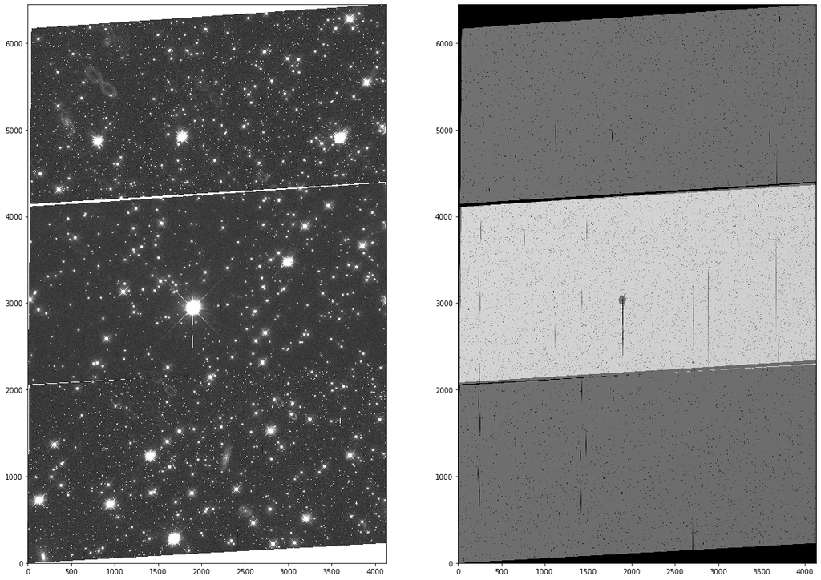

```python
# Display the combined science and weight images

sci = fits.getdata('f606w_drc_sci.fits')
wht = fits.getdata('f606w_drc_wht.fits')

fig = plt.figure(figsize=(20, 20))
ax1 = fig.add_subplot(1, 2, 1)
ax2 = fig.add_subplot(1, 2, 2)

ax1.imshow(sci, vmin=-0.05, vmax=0.4, cmap='Greys_r', origin='lower')
ax2.imshow(wht, vmin=0, vmax=1000, cmap='Greys_r', origin='lower')
```

## Conclusions

Many other services have interfaces for querying catalogs which could also be used to align HST images. In general, Gaia works very well for HST due to it's high precision, but can have a low number of sources in some regions, especially at high galactic latitudes. Aligning images to an absolute frame provides an easy way to make data comparable across many epochs/detectors/observatories, and in many cases, makes the alignment much easier.

# About this Notebook

```
Author: V. Bajaj, STScI WFC3 Team
Updated: December 14, 2018
```